# LCMS data preprocessing and analysis with xcms

16 May 2019

#### Package

xcms 3.6.1

**Package**: *xcms*  
**Authors**: Johannes Rainer  
**Modified**: 2019-05-02 16:53:29  
**Compiled**: Thu May 16 21:09:20 2019

# 1 Introduction

This documents describes data import, exploration, preprocessing and analysis of LCMS experiments with `xcms` version >= 3. The examples and basic workflow was adapted from the original *LC/MS Preprocessing and Analysis with xcms* vignette from Colin A. Smith.

The new user interface and methods use the `XCMSnExp` object (instead of the *old* `xcmsSet` object) as a container for the pre-processing results. To support packages and pipelines relying on the `xcmsSet` object, it is however possible to convert an `XCMSnExp` into a `xcmsSet` object using the `as` method (i.e.`xset <- as(x, "xcmsSet")`, with `x` being an `XCMSnExp` object.

# 2 Data import

`xcms` supports analysis of LC/MS data from files in (AIA/ANDI) NetCDF, mzML/mzXML and mzData format. For the actual data import Bioconductor’s *mzR* is used. For demonstration purpose we will analyze a subset of the data from [1] in which the metabolic consequences of knocking out the fatty acid amide hydrolase (FAAH) gene in mice was investigated. The raw data files (in NetCDF format) are provided with the `faahKO` data package. The data set consists of samples from the spinal cords of 6 knock-out and 6 wild-type mice. Each file contains data in centroid mode acquired in positive ion mode form 200-600 m/z and 2500-4500 seconds.

Below we load all required packages, locate the raw CDF files within the `faahKO` package and build a *phenodata* data frame describing the experimental setup.

```r
library(xcms)
library(faahKO)
library(RColorBrewer)
library(pander)
library(magrittr)
library(pheatmap)

## Get the full path to the CDF files
cdfs <- dir(system.file("cdf", package = "faahKO"), full.names = TRUE,
            recursive = TRUE)
## Create a phenodata data.frame
pd <- data.frame(sample_name = sub(basename(cdfs), pattern = ".CDF",
                                   replacement = "", fixed = TRUE),
                 sample_group = c(rep("KO", 6), rep("WT", 6)),
                 stringsAsFactors = FALSE)
```

Subsequently we load the raw data as an `OnDiskMSnExp` object using the `readMSData` method from the *MSnbase* package. The `MSnbase` provides based structures and infrastructure for the processing of mass spectrometry data. Also, `MSnbase` can be used to *centroid* profile-mode MS data (see the corresponding vignette in the `MSnbase` package).

```r
raw_data <- readMSData(files = cdfs, pdata = new("NAnnotatedDataFrame", pd),
                       mode = "onDisk")
```

The resulting `OnDiskMSnExp` object contains general information about the number of spectra, retention times, the measured total ion current etc, but does not contain the full raw data (i.e. the m/z and intensity values from each measured spectrum). Its memory footprint is thus rather small making it an ideal object to represent large metabolomics experiments while allowing to perform simple quality controls, data inspection and exploration as well as data sub-setting operations. The m/z and intensity values are imported from the raw data files on demand, hence the location of the raw data files should not be changed after initial data import.

# 3 Initial data inspection

The `OnDiskMSnExp` organizes the MS data by spectrum and provides the methods `intensity`, `mz` and `rtime` to access the raw data from the files (the measured intensity values, the corresponding m/z and retention time values). In addition, the `spectra` method could be used to return all data encapsulated in `Spectrum` objects. Below we extract the retention time values from the object.

```r
head(rtime(raw_data))
```

```
## F01.S0001 F01.S0002 F01.S0003 F01.S0004 F01.S0005 F01.S0006
##  2501.378  2502.943  2504.508  2506.073  2507.638  2509.203
```

All data is returned as one-dimensional vectors (a numeric vector for `rtime` and a `list` of numeric vectors for `mz` and `intensity`, each containing the values from one spectrum), even if the experiment consists of multiple files/samples. The `fromFile` function returns an integer vector providing the mapping of the values to the originating file. Below we use the `fromFile` indices to organize the `mz` values by file.

```r
mzs <- mz(raw_data)

## Split the list by file
mzs_by_file <- split(mzs, f = fromFile(raw_data))

length(mzs_by_file)
```

```
## [1] 12
```

As a first evaluation of the data we plot below the base peak chromatogram (BPC) for each file in our experiment. We use the `chromatogram` method and set the `aggregationFun` to `"max"` to return for each spectrum the maximal intensity and hence create the BPC from the raw data. To create a total ion chromatogram we could set `aggregationFun` to `sum`.

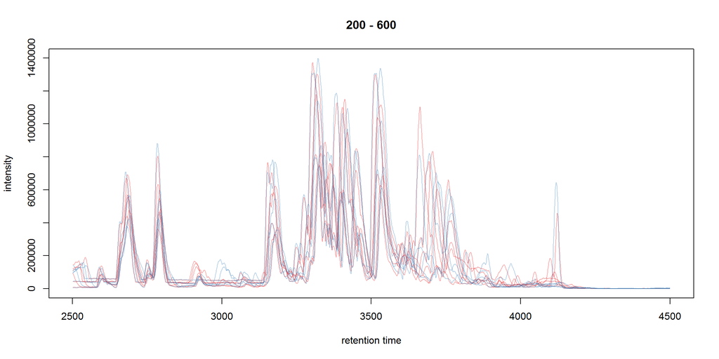

```r
## Get the base peak chromatograms. This reads data from the files.
bpis <- chromatogram(raw_data, aggregationFun = "max")
## Define colors for the two groups
group_colors <- paste0(brewer.pal(3, "Set1")[1:2], "60")
names(group_colors) <- c("KO", "WT")

## Plot all chromatograms.
plot(bpis, col = group_colors[raw_data$sample_group])
```

The `chromatogram` method returned a `Chromatograms` object that organizes individual `Chromatogram` objects (which in fact contain the chromatographic data) in a two-dimensional array: columns represent samples and rows (optionally) m/z and/or retention time ranges. Below we extract the chromatogram of the first sample and access its retention time and intensity values.

```r
bpi_1 <- bpis[1, 1]
head(rtime(bpi_1))
```

```
## F01.S0001 F01.S0002 F01.S0003 F01.S0004 F01.S0005 F01.S0006
##  2501.378  2502.943  2504.508  2506.073  2507.638  2509.203
```

```r
head(intensity(bpi_1))
```

```
## F01.S0001 F01.S0002 F01.S0003 F01.S0004 F01.S0005 F01.S0006
##     43888     43960     43392     42632     42200     42288
```

The `chromatogram` method supports also extraction of chromatographic data from a m/z-rt slice of the MS data. In the next section we will use this method to create an extracted ion chromatogram (EIC) for a selected peak.

Note that `chromatogram` reads the raw data from each file to calculate the chromatogram. The `bpi` and `tic` methods on the other hand do not read any data from the raw files but use the respective information that was provided in the header definition of the input files (which might be different from the actual data).

Below we create boxplots representing the distribution of total ion currents per file. Such plots can be very useful to spot problematic or failing MS runs.

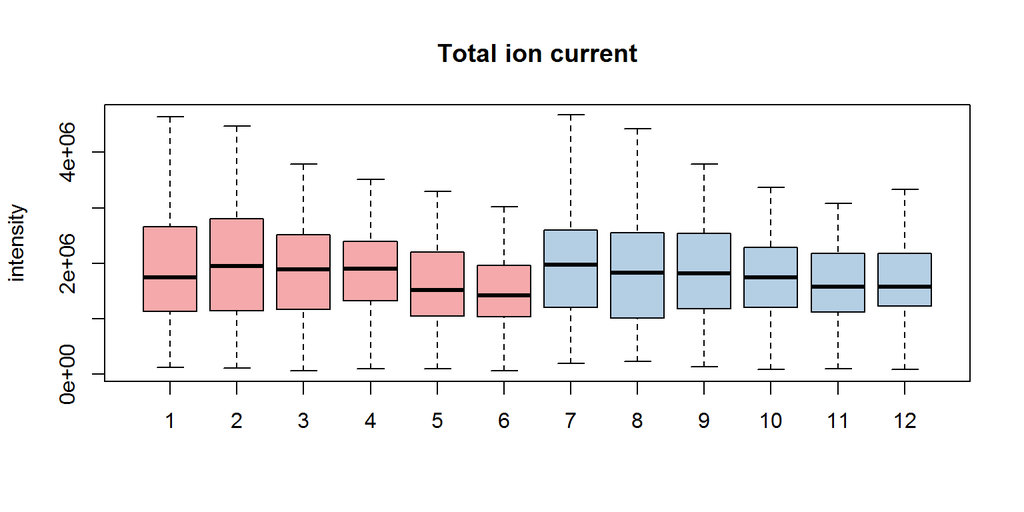

Figure 1: Distribution of total ion currents per file

```r
## Get the total ion current by file
tc <- split(tic(raw_data), f = fromFile(raw_data))
boxplot(tc, col = group_colors[raw_data$sample_group],
        ylab = "intensity", main = "Total ion current")
```

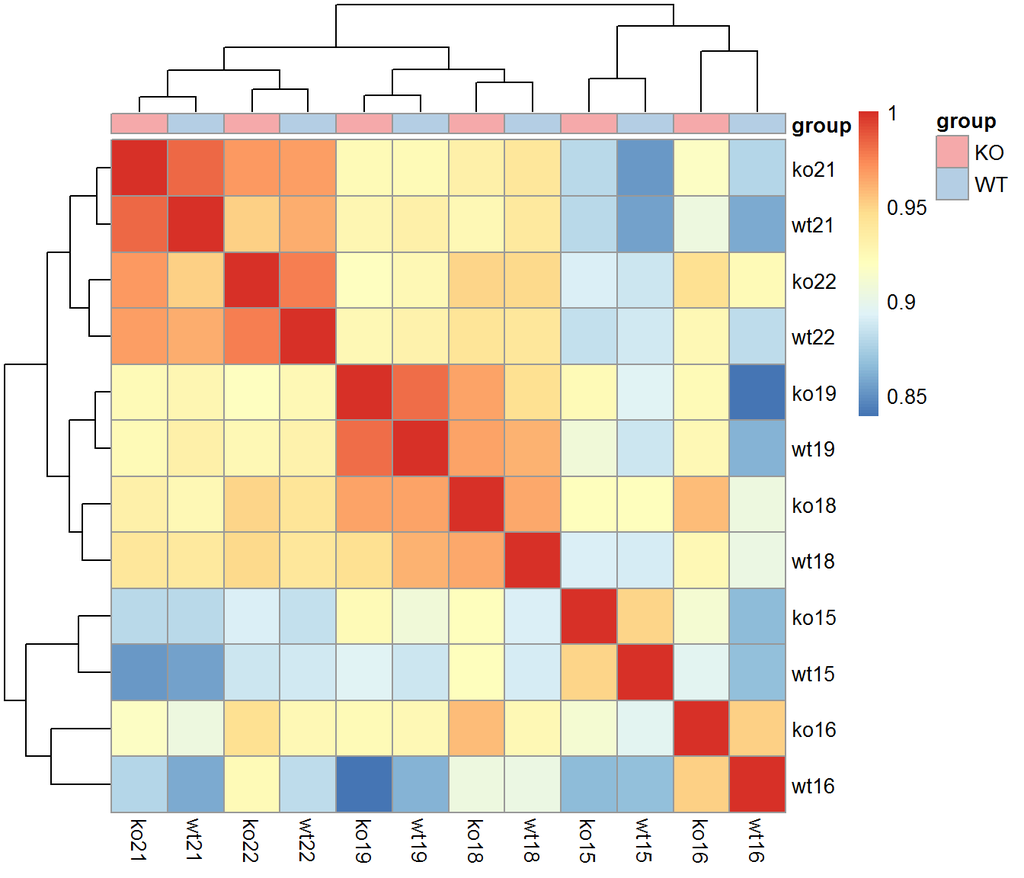

Figure 2: Grouping of samples based on similarity of their base peak chromatogram

```r
## Bin the BPC
bpis_bin <- bin(bpis, binSize = 2)

## Calculate correlation on the log2 transformed base peak intensities
cormat <- cor(log2(do.call(cbind, lapply(bpis_bin, intensity))))
colnames(cormat) <- rownames(cormat) <- raw_data$sample_name

## Define which phenodata columns should be highlighted in the plot
ann <- data.frame(group = raw_data$sample_group)
rownames(ann) <- raw_data$sample_name

## Perform the cluster analysis
pheatmap(cormat, annotation = ann,
         annotation_color = list(group = group_colors))
```

The samples cluster in a pairwise manner, the KO and WT samples for the sample index having the most similar BPC. In addition, 3 larger clusters are present grouping KO and WT samples 21 and 22 together as well as 18 and 19. KO and WT samples 15 and 16 separate from these two clusters.

# 4 Chromatographic peak detection

Next we perform the chromatographic peak detection using the *centWave* algorithm [2]. Before running the peak detection it is however strongly suggested to visually inspect e.g. the extracted ion chromatogram of internal standards or known compounds to evaluate and adapt the peak detection settings since the default settings will not be appropriate for most LCMS experiments. The two most critical parameters for *centWave* are the `peakwidth` (expected range of chromatographic peak widths) and `ppm` (maximum expected deviation of m/z values of centroids corresponding to one chromatographic peak; this is usually much larger than the ppm specified by the manufacturer) parameters. To evaluate the typical chromatographic peak width we plot the EIC for one peak.

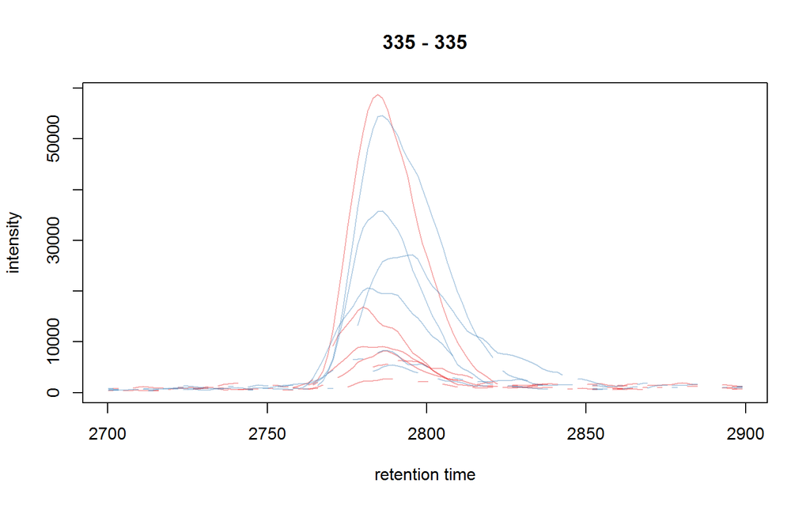

Figure 3: Extracted ion chromatogram for one peak

```r
## Define the rt and m/z range of the peak area
rtr <- c(2700, 2900)
mzr <- c(334.9, 335.1)
## extract the chromatogram
chr_raw <- chromatogram(raw_data, mz = mzr, rt = rtr)
plot(chr_raw, col = group_colors[chr_raw$sample_group])
```

Note that `Chromatogram` objects extracted by the `chromatogram` method contain an `NA` value if in a certain scan (i.e. for a specific retention time) no signal was measured in the respective mz range. This is reflected by the lines not being drawn as continuous lines in the plot above.

The peak above has a width of about 50 seconds. The `peakwidth` parameter should be set to accommodate the expected widths of peak in the data set. We set it to `20,80` for the present example data set.

For the `ppm` parameter we extract the full MS data (intensity, retention time and m/z values) corresponding to the above peak. To this end we first filter the raw object by retention time, then by m/z and finally plot the object with`type = "XIC"` to produce the plot below. We use the *pipe* (`%>%`) command better illustrate the corresponding workflow.

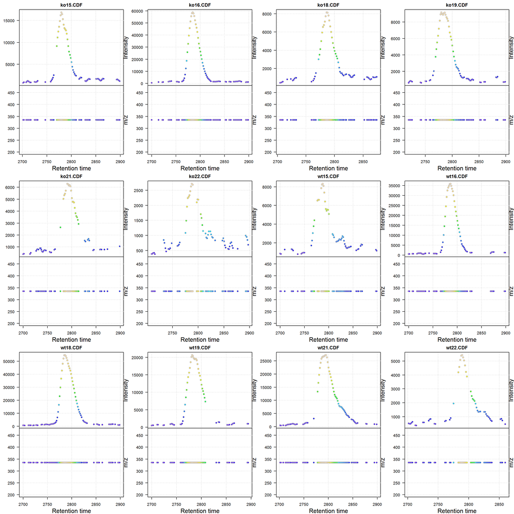

Figure 4: Visualization of the raw MS data for one peak  
For each plot: upper panel: chromatogram plotting the intensity values against the retention time, lower panel m/z against retention time plot. The individual data points are colored according to the intensity.

```r
raw_data %>%
    filterRt(rt = rtr) %>%
    filterMz(mz = mzr) %>%
    plot(type = "XIC")
```

In the present data there is actually no variation in the m/z values. Usually one would see the m/z values (lower panel) scatter around the *real* m/z value of the compound. The first step of the *centWave* algorithm defines so called regions of interest (ROI) based on the difference of m/z values from consecutive scans. In detail, m/z values from consecutive scans are included into a ROI if the difference between the m/z and the mean m/z of the ROI is smaller than the user defined `ppm` parameter. A reasonable choice for the `ppm` could thus be the maximal m/z difference of data points from neighboring scans/spectra that are part of the chromatographic peak. It is suggested to inspect the ranges of m/z values for many compounds (either internal standards or compounds known to be present in the sample) and define the `ppm` parameter for *centWave* according to these.

Note that we can also perform the peak detection on the extracted ion chromatogram. This can help to evaluate different peak detection settings. Only be aware that peak detection on an extracted ion chromatogram will not consider the `ppm` parameter and that the estimation of the background signal is different to the peak detection on the full data set; values for the `snthresh` will hence have different consequences. Below we perform the peak detection with the `findChromPeaks` function on the extracted ion chromatogram. The submitted *parameter* object defines which algorithm will be used and allows to define the settings for this algorithm. We use the *centWave* algorithm with default settings, except for `snthresh`.

```r
xchr <- findChromPeaks(chr_raw, param = CentWaveParam(snthresh = 2))
```

We can access the identified chromatographic peaks with the `chromPeaks` function.

```r
head(chromPeaks(xchr))
```

```
##            rt    rtmin    rtmax       into       intb  maxo sn row column
## [1,] 2781.505 2761.160 2809.674  412134.25  355516.37 16856 13   1      1
## [2,] 2786.199 2764.290 2812.803 1496244.21 1391821.33 58736 20   1      2
## [3,] 2786.201 2764.291 2812.805  211297.25  176419.81  8158  8   1      3
## [4,] 2783.069 2762.725 2812.804  285228.07  144930.91  9154  2   1      4
## [5,] 2734.556 2714.211 2765.855   21579.37   18449.43   899  4   1      5
## [6,] 2797.154 2775.245 2815.933  159058.78  150289.31  6295 12   1      5
```

```r
chromPeakData(xchr)
```

```
## DataFrame with 16 rows and 4 columns
##      ms_level is_filled       row    column
##     <integer> <logical> <integer> <integer>
## 1           1     FALSE         1         1
## 2           1     FALSE         1         2
## 3           1     FALSE         1         3
## 4           1     FALSE         1         4
## 5           1     FALSE         1         5
## ...       ...       ...       ...       ...
## 12          1     FALSE         1         8
## 13          1     FALSE         1         9
## 14          1     FALSE         1        10
## 15          1     FALSE         1        11
## 16          1     FALSE         1        12
```

Next we plot the identified chromatographic peaks in the extracted ion chromatogram. We use the `col` parameter to color the individual chromatogram lines. Colors can also be specified for the identified peaks, `peakCol` for the foreground/border color, `peakBg` for the background/fill color. One color has to be provided for each chromatographic peak listed by `chromPeaks`. Below we define a color to indicate the sample group from which the sample is and use the sample information in the peaks’ `"sample"` column to assign the correct color to each chromatographic peak. More peak highlighting options are described further below.

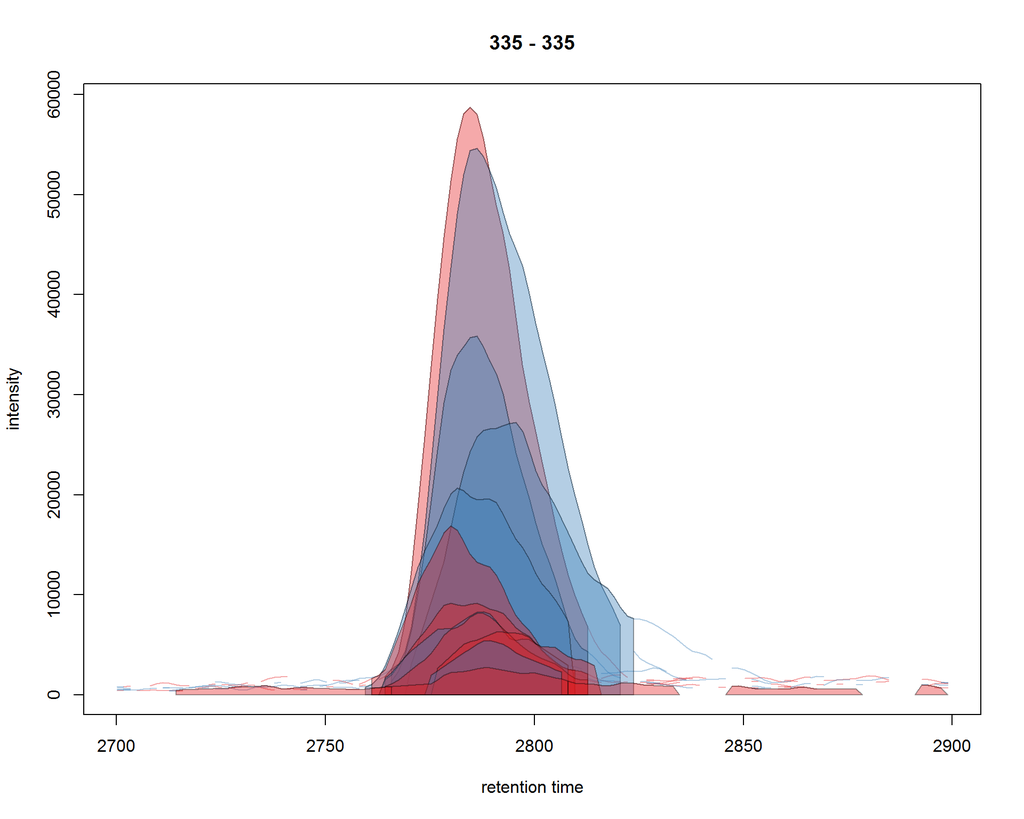

Figure 5: Signal for an example peak  
Red and blue colors represent KO and wild type samples, respectively. Peak area of identified chromatographic peaks are highlighted in the sample group color.

```r
sample_colors <- group_colors[xchr$sample_group]
plot(xchr, col = sample_colors,
     peakBg = sample_colors[chromPeaks(xchr)[, "column"]])
```

Finally we perform the chromatographic peak detection on the full data set. Note that we set the argument `noise` to `5000` to reduce the run time of this vignette. With this setting we consider only signals with a value larger than 5000 in the peak detection step.

```r
cwp <- CentWaveParam(peakwidth = c(20, 80), noise = 5000)
xdata <- findChromPeaks(raw_data, param = cwp)
```

The results are returned as an `XCMSnExp` object which extends the `OnDiskMSnExp` object by storing also LC/GC-MS preprocessing results. This means also that all methods to sub-set and filter the data or to access the (raw) data are inherited from the `OnDiskMSnExp` object and can thus be re-used. The results from the chromatographic peak detection can be accessed with the `chromPeaks` method.

```r
head(chromPeaks(xdata))
```

```
##           mz mzmin mzmax       rt    rtmin    rtmax      into      intb
## CP0001 453.2 453.2 453.2 2509.203 2501.378 2527.982 1007409.0 1007380.8
## CP0002 236.1 236.1 236.1 2518.593 2501.378 2537.372  253501.0  226896.3
## CP0003 594.0 594.0 594.0 2601.535 2581.191 2637.529  161042.2  149297.3
## CP0004 577.0 577.0 577.0 2604.665 2581.191 2626.574  136105.2  129195.5
## CP0005 369.2 369.2 369.2 2587.451 2556.151 2631.269  483852.3  483777.1
## CP0006 369.2 369.2 369.2 2568.671 2557.716 2578.061  144624.8  144602.9
##         maxo    sn sample
## CP0001 38152 38151      1
## CP0002 12957    11      1
## CP0003  7850    13      1
## CP0004  6215    13      1
## CP0005  7215  7214      1
## CP0006  7033  7032      1
```

The returned `matrix` provides the m/z and retention time range for each identified chromatographic peak as well as the integrated signal intensity (“into”) and the maximal peak intensitity (“maxo”). Columns “sample” contains the index of the sample in the object/experiment in which the peak was identified.

Annotations for each individual peak can be extracted with the `chromPeakData` function. This data frame could also be used to add/store arbitrary annotations for each detected peak.

```r
chromPeakData(xdata)
```

```
## DataFrame with 5302 rows and 2 columns
##         ms_level is_filled
##        <integer> <logical>
## CP0001         1     FALSE
## CP0002         1     FALSE
## CP0003         1     FALSE
## CP0004         1     FALSE
## CP0005         1     FALSE
## ...          ...       ...
## CP5298         1     FALSE
## CP5299         1     FALSE
## CP5300         1     FALSE
## CP5301         1     FALSE
## CP5302         1     FALSE
```

Below we use the data from the `chromPeaks` matrix to calculate some per-file summaries.

```r
summary_fun <- function(z)
    c(peak_count = nrow(z), rt = quantile(z[, "rtmax"] - z[, "rtmin"]))

T <- lapply(split.data.frame(
    chromPeaks(xdata), f = chromPeaks(xdata)[, "sample"]),
    FUN = summary_fun)
T <- do.call(rbind, T)
rownames(T) <- basename(fileNames(xdata))
pandoc.table(T,
             caption = paste0("Summary statistics on identified chromatographic",
                              " peaks. Shown are number of identified peaks per",
                              " sample and widths/duration of chromatographic ",
                              "peaks."))
```

Summary statistics on identified chromatographic peaks Shown are number of identified peaks per sample and widths/duration of chromatographic peaks.

|  | peak_count | rt.0% | rt.25% | rt.50% | rt.75% | rt.100% |
| --- | --- | --- | --- | --- | --- | --- |
| **ko15.CDF** | 561 | 7.824 | 28.17 | 39.12 | 50.08 | 139.3 |
| **ko16.CDF** | 741 | 4.695 | 23.47 | 39.12 | 50.08 | 148.7 |
| **ko18.CDF** | 448 | 4.694 | 28.17 | 42.25 | 53.21 | 173.7 |
| **ko19.CDF** | 333 | 7.824 | 31.3 | 46.95 | 59.47 | 181.5 |
| **ko21.CDF** | 276 | 1.565 | 35.99 | 48.51 | 61.03 | 164.3 |
| **ko22.CDF** | 325 | 7.824 | 26.61 | 43.82 | 56.34 | 126.8 |
| **wt15.CDF** | 564 | 4.695 | 26.6 | 39.12 | 50.08 | 161.2 |
| **wt16.CDF** | 507 | 7.824 | 28.17 | 40.69 | 53.21 | 151.8 |
| **wt18.CDF** | 443 | 3.13 | 26.61 | 42.25 | 57.12 | 192.5 |
| **wt19.CDF** | 350 | 7.824 | 31.3 | 45.38 | 57.9 | 184.7 |
| **wt21.CDF** | 317 | 3.13 | 28.17 | 45.38 | 61.03 | 172.1 |
| **wt22.CDF** | 437 | 1.565 | 26.61 | 40.69 | 53.21 | 161.2 |

We can also plot the location of the identified chromatographic peaks in the m/z - retention time space for one file using the `plotChromPeaks` function. Below we plot the chromatographic peaks for the 3rd sample.

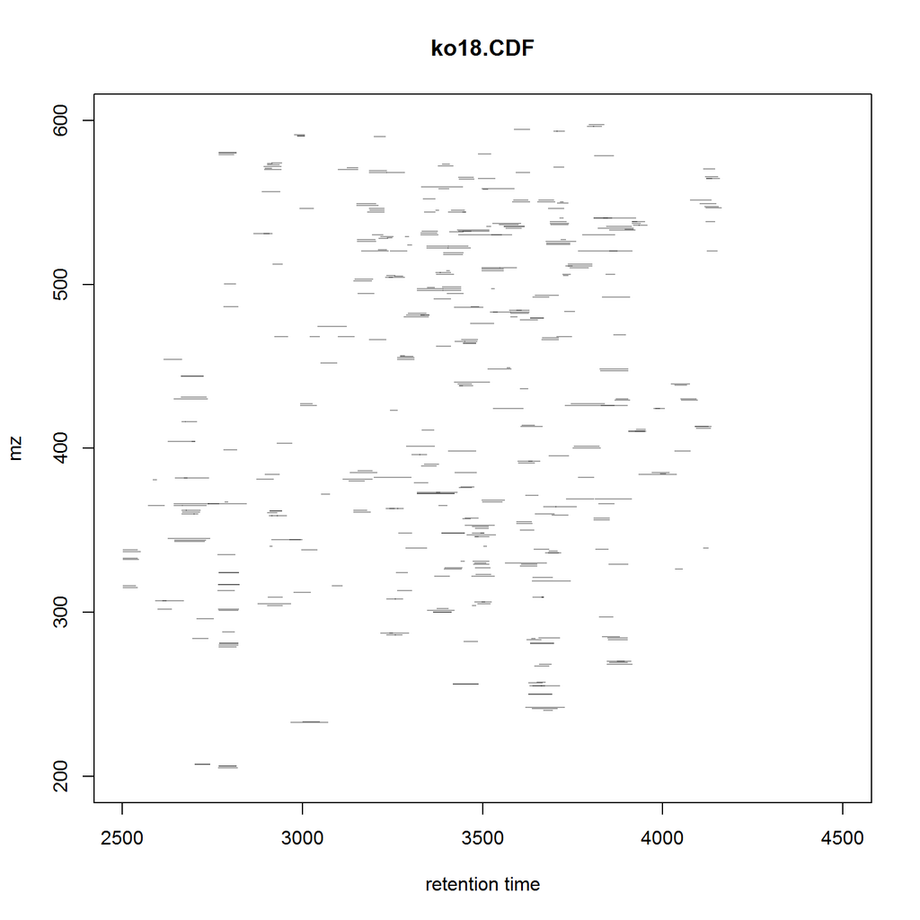

Figure 6: Identified chromatographic peaks in the m/z by retention time space for one sample

```r
plotChromPeaks(xdata, file = 3)
```

To get a global overview of the peak detection we can plot the frequency of identified peaks per file along the retention time axis. This allows to identify time periods along the MS run in which a higher number of peaks was identified and evaluate whether this is consistent across files.

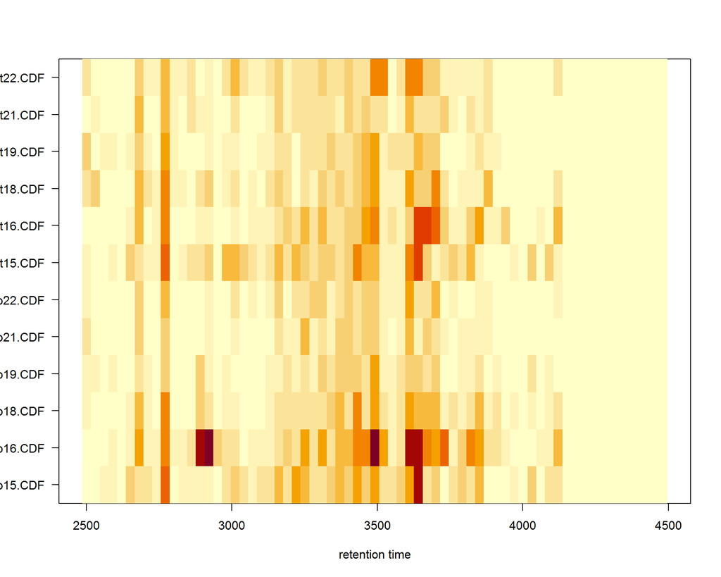

```r
plotChromPeakImage(xdata)
```

Next we highlight the identified chromatographic peaks for the example peak from before. Evaluating such plots on a list of peaks corresponding to known peaks or internal standards helps to ensure that peak detection settings were appropriate and correctly identified the expected peaks. We extract the ion chromatogram from the peak detection result object, which contains then also the identified chromatographic peaks for that ion that we can extract with the `chromPeaks` function.

```r
chr_ex <- chromatogram(xdata, mz = mzr, rt = rtr)
chromPeaks(chr_ex)
```

```
##         mz mzmin mzmax       rt    rtmin    rtmax       into       intb
## CP0057 335   335   335 2781.505 2761.160 2809.674  412134.25  383167.42
## CP0628 335   335   335 2786.199 2764.290 2812.803 1496244.21 1461187.31
## CP1349 335   335   335 2786.201 2764.291 2812.805  211297.25  194283.05
## CP1795 335   335   335 2783.069 2762.725 2812.804  285228.07  264248.60
## CP2120 335   335   335 2797.154 2775.245 2815.933  159058.78  149229.62
## CP3308 335   335   335 2786.199 2764.290 2812.803  932645.21  915333.83
## CP3838 335   335   335 2787.765 2765.855 2820.629 1636669.03 1603950.74
## CP4254 335   335   335 2784.635 2759.595 2809.674  643673.21  631119.07
## CP4601 335   335   335 2792.461 2768.987 2823.760  876585.53  848569.14
## CP4906 335   335   335 2789.329 2773.680 2806.544   89582.57   83926.74
##         maxo sn sample row column
## CP0057 16856 23      1   1      1
## CP0628 58736 72      2   1      2
## CP1349  8158 15      3   1      3
## CP1795  9154 18      4   1      4
## CP2120  6295 13      5   1      5
## CP3308 35856 66      8   1      8
## CP3838 54640 78      9   1      9
## CP4254 20672 54     10   1     10
## CP4601 27200 36     11   1     11
## CP4906  5427 12     12   1     12
```

We can also plot the extracted ion chromatogram. Identified chromatographic peaks will be automatically highlighted in the plot. Below we highlight chromatographic peaks with a rectangle from the peak’s minimal to maximal rt and from an intensity of 0 to the maximal signal of the peak.

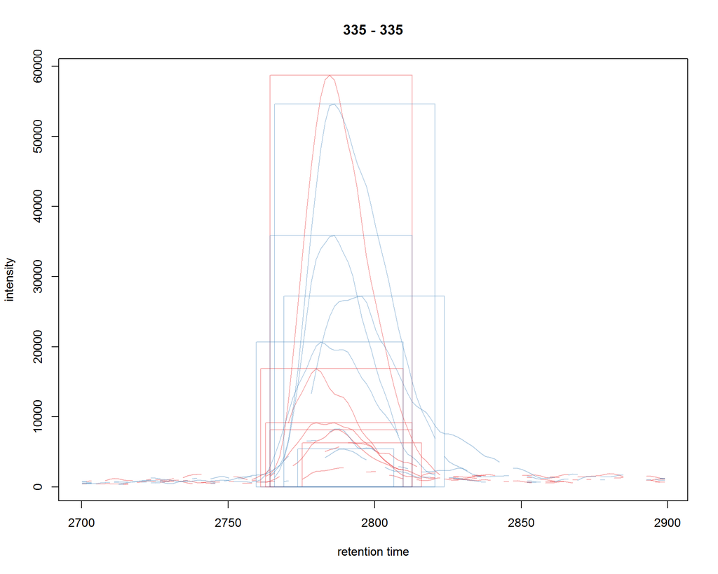

Figure 8: Signal for an example peak  
Red and blue colors represent KO and wild type samples, respectively. The rectangles indicate the identified chromatographic peaks per sample.

```r
sample_colors <- group_colors[chr_ex$sample_group]
plot(chr_ex, col = sample_colors, peakType = "rectangle",
     peakCol = sample_colors[chromPeaks(chr_ex)[, "sample"]],
     peakBg = NA)
```

Alternatively to the rectangle visualization above, it is possible to represent the apex position of each peak with a single point (passing argument `type = "point"` to the function), or draw the actually identified peak by specifying `type = "polygon"`. To completely omit highlighting the identified peaks (e.g. to plot base peak chromatograms or similar) `type = "none"` can be used. Below we use `type = "polygon"` to fill the peak area for each identified chromatographic peak in each sample. Whether individual peaks can be still identified in such a plot depends however on the number of samples from which peaks are drawn.

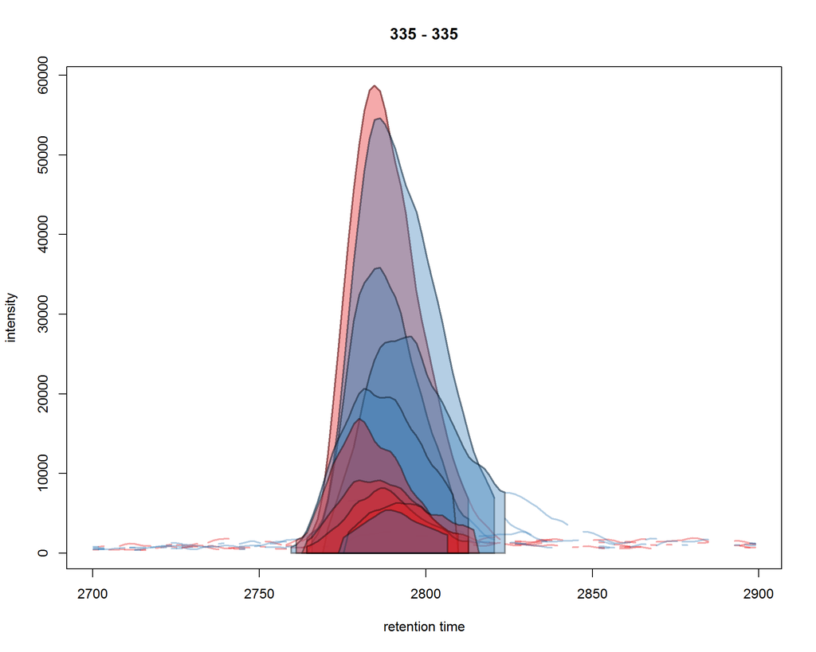

Figure 9: Signal for an example peak  
Red and blue colors represent KO and wild type samples, respectively. The signal area of identified chromatographic peaks are filled with a color.

```r
plot(chr_ex, col = group_colors[chr_raw$sample_group], lwd = 2,
     peakBg = sample_colors[chromPeaks(chr_ex)[, "sample"]])
```

Note that we can also specifically extract identified chromatographic peaks for a selected region by providing the respective m/z and retention time ranges with the `mz` and `rt` arguments in the `chromPeaks` method.

```r
pander(chromPeaks(xdata, mz = mzr, rt = rtr),
       caption = paste("Identified chromatographic peaks in a selected ",
                       "m/z and retention time range."))
```

Identified chromatographic peaks in a selected m/z and retention time range (continued below)

|  | mz | mzmin | mzmax | rt | rtmin | rtmax | into | intb |
| --- | --- | --- | --- | --- | --- | --- | --- | --- |
| **CP0057** | 335 | 335 | 335 | 2782 | 2761 | 2810 | 412134 | 383167 |
| **CP0628** | 335 | 335 | 335 | 2786 | 2764 | 2813 | 1496244 | 1461187 |
| **CP1349** | 335 | 335 | 335 | 2786 | 2764 | 2813 | 211297 | 194283 |
| **CP1795** | 335 | 335 | 335 | 2783 | 2763 | 2813 | 285228 | 264249 |
| **CP2120** | 335 | 335 | 335 | 2797 | 2775 | 2816 | 159059 | 149230 |
| **CP3308** | 335 | 335 | 335 | 2786 | 2764 | 2813 | 932645 | 915334 |
| **CP3838** | 335 | 335 | 335 | 2788 | 2766 | 2821 | 1636669 | 1603951 |
| **CP4254** | 335 | 335 | 335 | 2785 | 2760 | 2810 | 643673 | 631119 |
| **CP4601** | 335 | 335 | 335 | 2792 | 2769 | 2824 | 876586 | 848569 |
| **CP4906** | 335 | 335 | 335 | 2789 | 2774 | 2807 | 89583 | 83927 |

|  | maxo | sn | sample |
| --- | --- | --- | --- |
| **CP0057** | 16856 | 23 | 1 |
| **CP0628** | 58736 | 72 | 2 |
| **CP1349** | 8158 | 15 | 3 |
| **CP1795** | 9154 | 18 | 4 |
| **CP2120** | 6295 | 13 | 5 |
| **CP3308** | 35856 | 66 | 8 |
| **CP3838** | 54640 | 78 | 9 |
| **CP4254** | 20672 | 54 | 10 |
| **CP4601** | 27200 | 36 | 11 |
| **CP4906** | 5427 | 12 | 12 |

Finally we plot also the distribution of peak intensity per sample. This allows to investigate whether systematic differences in peak signals between samples are present.

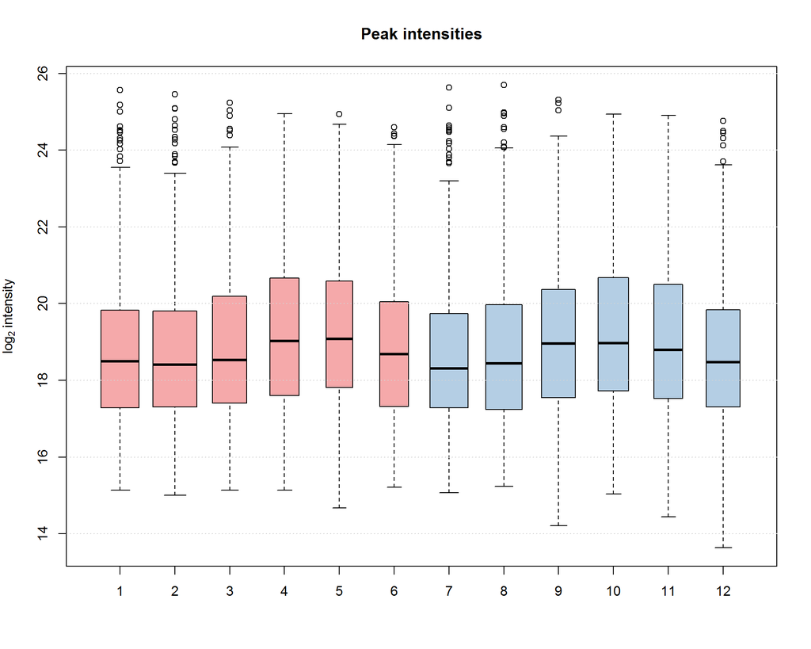

Figure 10: Peak intensity distribution per sample

```r
## Extract a list of per-sample peak intensities (in log2 scale)
ints <- split(log2(chromPeaks(xdata)[, "into"]),
              f = chromPeaks(xdata)[, "sample"])
boxplot(ints, varwidth = TRUE, col = group_colors[xdata$sample_group],
        ylab = expression(log[2]~intensity), main = "Peak intensities")
grid(nx = NA, ny = NULL)
```

# 5 Alignment

The time at which analytes elute in the chromatography can vary between samples (and even compounds). Such a difference was already observable in the extracted ion chromatogram plot shown as an example in the previous section. The alignment step, also referred to as retention time correction, aims at adjusting this by shifting signals along the retention time axis to align the signals between different samples within an experiment.

A plethora of alignment algorithms exist (see [3]), with some of them being implemented also in `xcms`. The method to perform the alignment/retention time correction in `xcms` is `adjustRtime` which uses different alignment algorithms depending on the provided parameter class.

In the example below we use the *obiwarp* method [4] to align the samples. We use a `binSize = 0.6` which creates warping functions in mz bins of 0.6. Also here it is advisable to modify the settings for each experiment and evaluate if retention time correction did align internal controls or known compounds properly.

```r
xdata <- adjustRtime(xdata, param = ObiwarpParam(binSize = 0.6))
```

`adjustRtime`, besides calculating adjusted retention times for each spectrum, does also adjust the reported retention times of the identified chromatographic peaks.

To extract the adjusted retention times we can use the `adjustedRtime` method, or simply the `rtime` method that, if present, returns by default adjusted retention times from an `XCMSnExp` object.

```r
## Extract adjusted retention times
head(adjustedRtime(xdata))
```

```
## F01.S0001 F01.S0002 F01.S0003 F01.S0004 F01.S0005 F01.S0006
##  2501.378  2502.958  2504.538  2506.118  2507.699  2509.280
```

```r
## Or simply use the rtime method
head(rtime(xdata))
```

```
## F01.S0001 F01.S0002 F01.S0003 F01.S0004 F01.S0005 F01.S0006
##  2501.378  2502.958  2504.538  2506.118  2507.699  2509.280
```

*Raw* retention times can be extracted from an `XCMSnExp` containing aligned data with `rtime(xdata, adjusted = FALSE)`.

To evaluate the impact of the alignment we plot the BPC on the adjusted data. In addition we plot the differences of the adjusted- to the raw retention times per sample using the `plotAdjustedRtime` function. Note that we **don’t** want to highlight any chromatographic peaks (because there would simply be too many) and set thus `peakType = "none"` in the `plot` call.

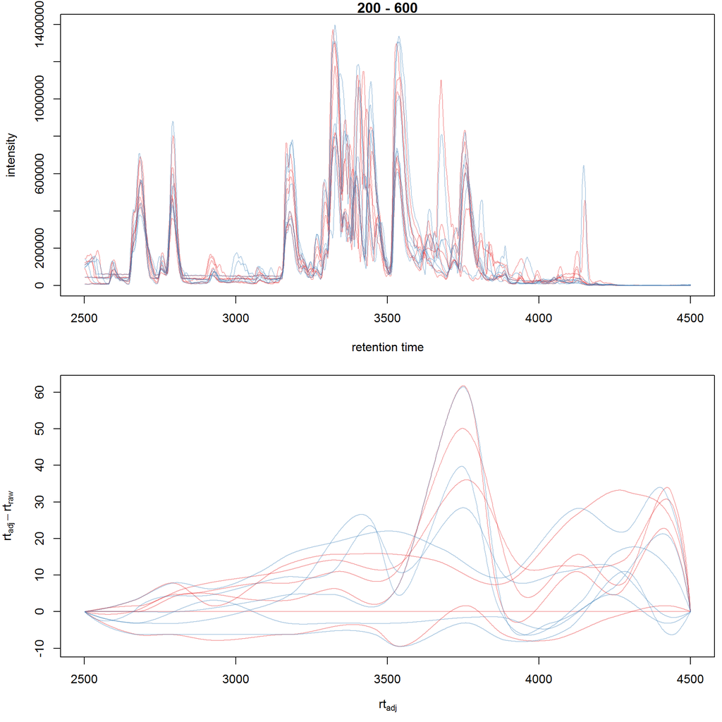

Figure 11: Obiwarp aligned data  
Base peak chromatogram after alignment (top) and difference between adjusted and raw retention times along the retention time axis (bottom).

```r
## Get the base peak chromatograms.
bpis_adj <- chromatogram(xdata, aggregationFun = "max")
par(mfrow = c(2, 1), mar = c(4.5, 4.2, 1, 0.5))
plot(bpis_adj, col = group_colors[bpis_adj$sample_group], peakType = "none")
## Plot also the difference of adjusted to raw retention time.
plotAdjustedRtime(xdata, col = group_colors[xdata$sample_group])
```

Too large differences between adjusted and raw retention times could indicate poorly performing samples or alignment.

Alternatively to *obiwarp* we could use the *peak groups* alignment method that adjusts the retention time by aligning previously identified *hook peaks* (chromatographic peaks present in most/all samples). Ideally, these hook peaks should span most part of the retention time range. Below we first restore the raw retention times (also of the identified peaks) using the `dropAdjustedRtime` methods. Note that a `drop*` method is available for each preprocessing step allowing to remove the respective results from the `XCMSnExp` object.

```r
## Does the object have adjusted retention times?
hasAdjustedRtime(xdata)
```

```
## [1] TRUE
```

```r
## Drop the alignment results.
xdata <- dropAdjustedRtime(xdata)

## Does the object have adjusted retention times?
hasAdjustedRtime(xdata)
```

```
## [1] FALSE
```

**Note**: `XCMSnExp` objects hold the raw along with the adjusted retention times and subsetting will in most cases drop the adjusted retention times. Sometimes it might thus be useful to **replace** the raw retention times with the adjusted retention times. This can be done with the `applyAdjustedRtime`.

As noted above the *peak groups* method requires peak groups (features) present in most samples to perform the alignment. We thus have to perform a first correspondence run to identify such peaks (details about the algorithm used are presented in the next section). We use here again default settings, but it is strongly advised to adapt the parameters for each data set. The definition of the sample groups (i.e. assignment of individual samples to the sample groups in the experiment) is mandatory for the `PeakDensityParam`. If there are no sample groups in the experiment `sampleGroups` should be set to a single value for each file (e.g. `rep(1, length(fileNames(xdata))`).

```r
## Correspondence: group peaks across samples.
pdp <- PeakDensityParam(sampleGroups = xdata$sample_group,
                        minFraction = 0.8)
xdata <- groupChromPeaks(xdata, param = pdp)

## Now the retention time correction.
pgp <- PeakGroupsParam(minFraction = 0.85)

## Get the peak groups that would be used for alignment.
xdata <- adjustRtime(xdata, param = pgp)
```

Note also that we could use the `adjustedRtimePeakGroups` method on the object before alignment to evaluate on which features (peak groups) the alignment would be performed. This can be useful to test different settings for the peak groups algorithm. Also, it is possible to manually select or define certain peak groups (i.e. their retention times per sample) and provide this matrix to the `PeakGroupsParam` class with the `peakGroupsMatrix` argument.

Below plot the difference between raw and adjusted retention times using the `plotAdjustedRtime` function, which, if the *peak groups* method is used for alignment, also highlights the peak groups used in the adjustment.

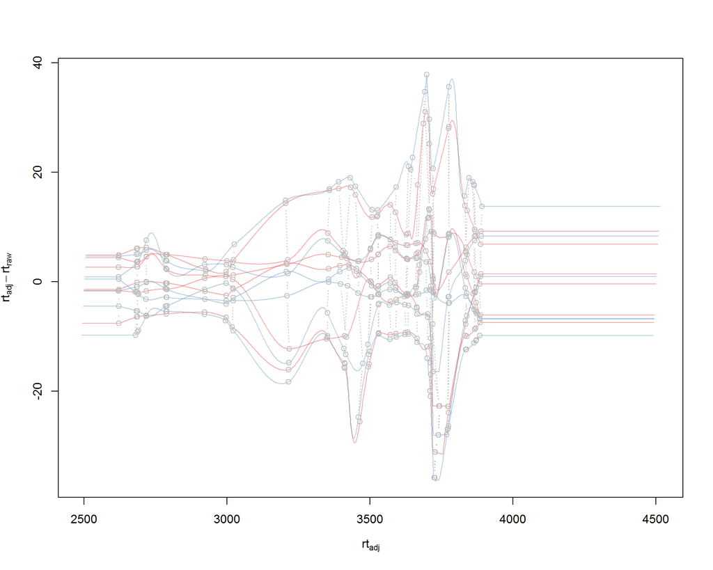

Figure 12: Peak groups aligned data

```r
## Plot the difference of adjusted to raw retention time.
plotAdjustedRtime(xdata, col = group_colors[xdata$sample_group],
                  peakGroupsCol = "grey", peakGroupsPch = 1)
```

At last we evaluate the impact of the alignment on the test peak.

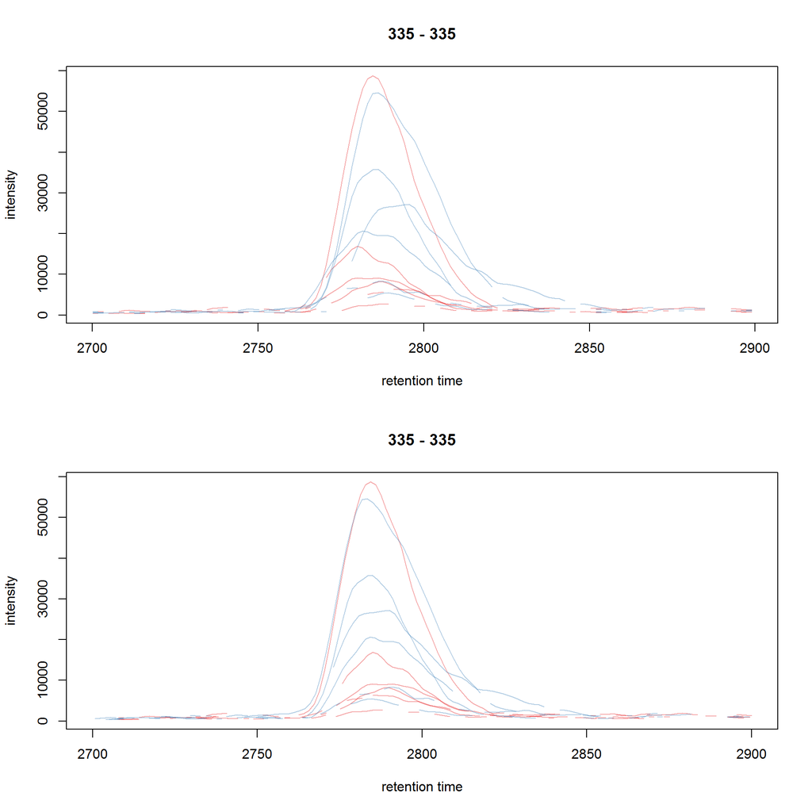

Figure 13: Example extracted ion chromatogram before (top) and after alignment (bottom)

```r
par(mfrow = c(2, 1))
## Plot the raw data
plot(chr_raw, col = group_colors[chr_raw$sample_group])

## Extract the chromatogram from the adjusted object
chr_adj <- chromatogram(xdata, rt = rtr, mz = mzr)
plot(chr_adj, col = group_colors[chr_raw$sample_group], peakType = "none")
```

## 5.1 Subset-based alignment

In some experiments it might be helpful to perform the alignment based on only a subset of the samples, e.g. if QC samples were injected at regular intervals or if the experiment contains blanks. Alignment method in `xcms` allow to estimate retention time drifts on a subset of samples (either all samples excluding blanks or QC samples injected at regular intervals during a measurement run) and use these to adjust the full data set.

Parameters `subset` (of the `PeakGroupsParam` or `ObiwarpParam` object) can be used to define the subset of samples on which the alignment of the full data set will be based (e.g. `subset` being the index of QC samples), and parameter `subsetAdjust` allows to specify the method by which the *left-out* samples will be adjusted. There are currently two options available:

- `subsetAdjust = "previous"`: adjust the retention times of a non-subset sample based on the alignment results of the previous subset sample (e.g. a QC sample). If samples are e.g. in the order *A1*, *B1*, *B2*, *A2*, *B3*, *B4* with *A* representing QC samples and *B* study samples, using `subset = c(1, 4)` and `subsetAdjust = "previous"` would result in all *A* samples to be aligned with each other and non-subset samples *B1* and *B2* being adjusted based on the alignment result of subset samples *A1* and *B3* and *B4* on those of *A2*.
- `subsetAdjust = "average"`: adjust retention times of non-subset samples based on an interpolation of the alignment results of the previous and subsequent subset sample. In the example above, *B1* would be adjusted based on the average of adjusted retention times between subset (QC) samples *A1* and *A2*. Since there is no subset sample after non-subset samples *B3* and *B4* these will be adjusted based on the alignment results of *A2* alone. Note that a weighted average is used to calculate the adjusted retention time averages, which uses the inverse of the difference of the index of the non-subset sample to the subset samples as weights. Thus, if we have a setup like *A1*, *B1*, *B2*, *A2* the adjusted retention times of *A1* would get a larger weight than those of *A2* in the adjustment of non-subset sample *B1* causing it’s adjusted retention times to be closer to those of *A1* than to *A2*. See below for examples.

Both cases require a meaningful/correct ordering of the samples within the object (e.g. ordering by injection index).

The examples below aim to illustrate the effect of these alignment options. First we assume samples 1, 6 and 11 in the *faahKO* data set to be QC samples (sample pools). We thus want to perform the alignment based on these samples and subsequently adjust the retention times of the left-out samples (2, 3, 4, 5, 7, 8, 9, 10 and 12) based on interpolation of the results from the neighboring *subset* samples. After initial peak grouping we perform below the alignment with the *peak groups* method passing the indices of the samples on which we want the alignment to be based with the `subset` argument and specify `subsetAdjust = "average"` to adjust the study samples based on interpolation of the alignment results from neighboring subset/QC samples.

Note that for any subset-alignment all parameters such as `minFraction` are relative to the `subset`, not the full experiment!

```r
xdata_subs <- dropAdjustedRtime(xdata)
## Define the experimental layout
xdata_subs$sample_type <- "study"
xdata_subs$sample_type[c(1, 6, 11)] <- "QC"

## Initial peak grouping. Use sample_type as grouping variable
pdp_subs <- PeakDensityParam(sampleGroups = xdata_subs$sample_type,
                             minFraction = 0.9)
xdata_subs <- groupChromPeaks(xdata_subs, param = pdp_subs)

## Define subset-alignment options and perform the alignment
pgp_subs <- PeakGroupsParam(minFraction = 0.85,
                            subset = which(xdata_subs$sample_type == "QC"),
                            subsetAdjust = "average", span = 0.4)
xdata_subs <- adjustRtime(xdata_subs, param = pgp_subs)
```

To illustrate the alignment results we plot the results only for samples 1 to 6 (1 and 6 being QC samples and 2 to 5 study samples that were adjusted based on the QC samples). This nicely shows how the interpolation of the `subsetAdjust = "average"` works: retention times of sample 2 are adjusted based on those from subset sample 1 and 6, giving however more weight to the closer subset sample 1 which results in the adjusted retention times of 2 being more similar to those of sample 1. Sample 5 on the other hand gets adjusted giving more weight to the second subset sample (6).

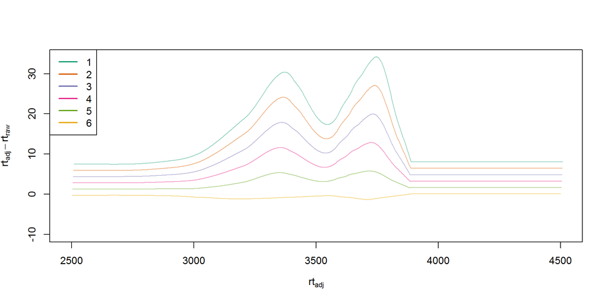

Figure 14: Alignment results for samples 1 to 6

```r
clrs <- rep(NA, 12)
clrs[1:6] <- paste0(brewer.pal(6, "Dark2"), 80)

plotAdjustedRtime(xdata_subs, col = clrs, lwd = 2, peakGroupsCol = NA)
legend("topleft", legend = 1:6, col = brewer.pal(6, "Dark2"), lwd = 2)
```

We also plot the full alignment results, drawing the `subset` samples as green and study samples as grey lines.

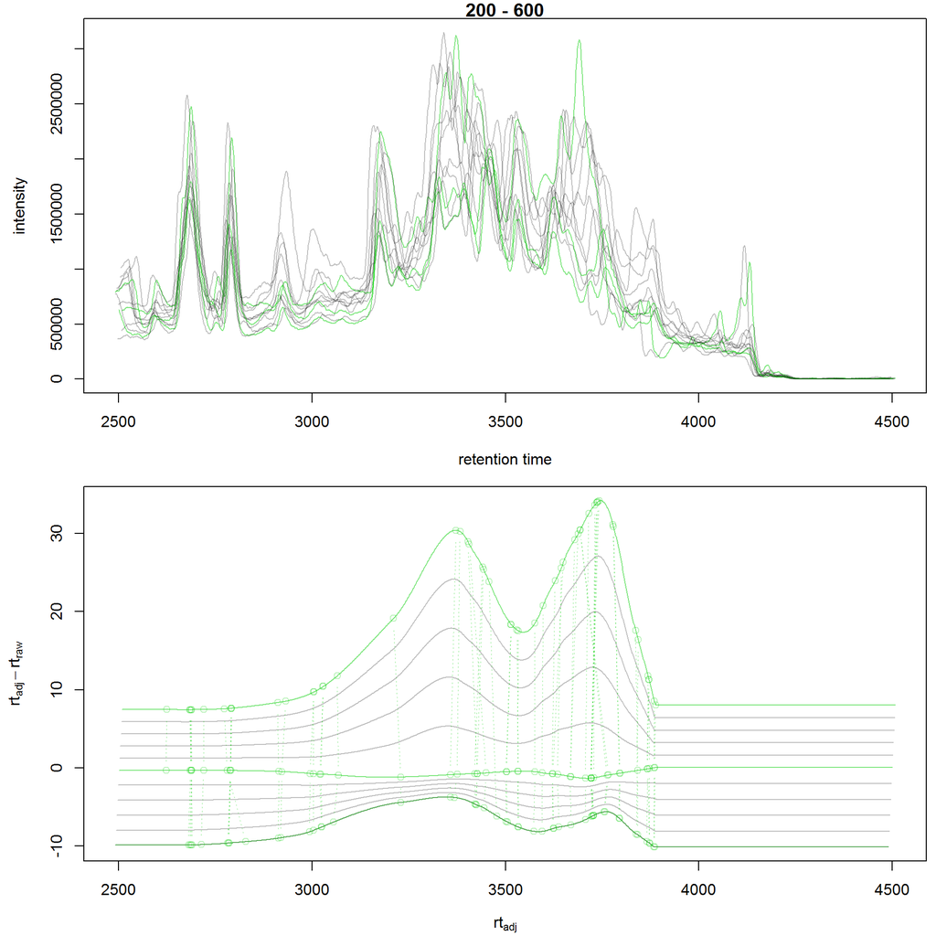

Figure 15: Subset-alignment results with option average  
Difference between adjusted and raw retention times along the retention time axis. Samples on which the alignment models were estimated are shown in green, study samples in grey.

```r
clrs <- rep("#00000040", 12)
clrs[xdata_subs$sample_type == "QC"] <- c("#00ce0080")
par(mfrow = c(2, 1), mar = c(4, 4.5, 1, 0.5))
plot(chromatogram(xdata_subs, aggregationFun = "sum"),
     col = clrs, peakType = "none")
plotAdjustedRtime(xdata_subs, col = clrs, peakGroupsPch = 1,
                  peakGroupsCol = "#00ce0040")
```

Option `subsetAdjust = "previous"` adjusts the retention times of a non-subset sample based on a single subset sample (the previous), which results in most cases in the adjusted retention times of the non-subset sample being highly similar to those of the subset sample which was used for adjustment.

Also obiwarp alignment supports the same types of subset-alignment as shown below.

```r
xdata_subs <- dropAdjustedRtime(xdata_subs)
```

```
## Reverting retention times of identified peaks to original values ... OK
```

```r
prm <- ObiwarpParam(subset = which(xdata_subs$sample_type == "QC"),
                    subsetAdjust = "average")
xdata_subs <- adjustRtime(xdata_subs, param = prm)
```

```
## Sample number 2 used as center sample.
## Aligning ko15.CDF against ko22.CDF ... OK
## Aligning wt21.CDF against ko22.CDF ... OK
## Aligning sample number 2 against subset ... OK
## Aligning sample number 3 against subset ... OK
## Aligning sample number 4 against subset ... OK
## Aligning sample number 5 against subset ... OK
## Aligning sample number 7 against subset ... OK
## Aligning sample number 8 against subset ... OK
## Aligning sample number 9 against subset ... OK
## Aligning sample number 10 against subset ... OK
## Aligning sample number 12 against subset ... OK
## Applying retention time adjustment to the identified chromatographic peaks ... OK
```

We again plot the results.

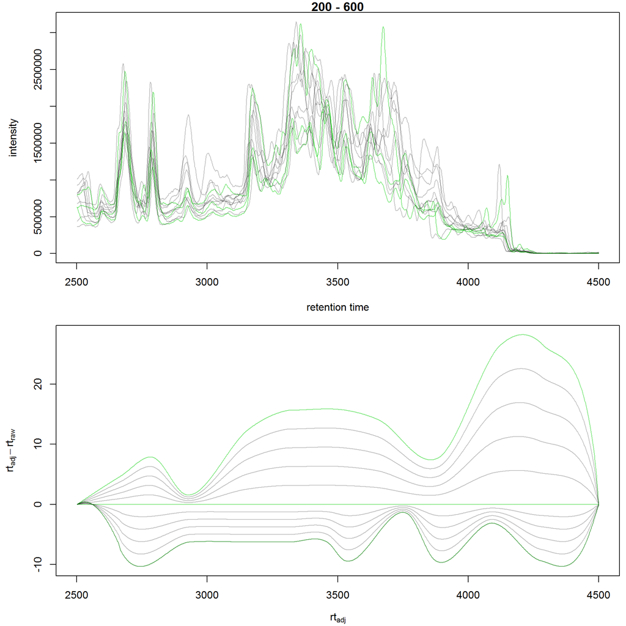

Figure 16: Obiwarp subset-alignment results with option average  
Difference between adjusted and raw retention times along the retention time axis. Samples on which the alignment models were estimated are shown in green, study samples in grey.

```r
clrs <- rep("#00000040", 12)
clrs[which(xdata_subs$sample_type == "QC")] <- "#00ce0080"
par(mfrow = c(2, 1), mar = c(4, 4.5, 1, 0.5))
plot(chromatogram(xdata_subs, aggregationFun = "sum"),
     col = clrs, peakType = "none")
plotAdjustedRtime(xdata_subs, col = clrs, peakGroupsPch = 1)
```

# 6 Correspondence

The final step in the metabolomics preprocessing is the correspondence that matches detected chromatographic peaks between samples (and depending on the settings, also within samples if they are adjacent). The method to perform the correspondence in `xcms` is `groupChromPeaks`. We will use the *peak density* method [5] to group chromatographic peaks. The algorithm combines chromatographic peaks depending on the density of peaks along the retention time axis within small slices along the mz dimension. To illustrate this we plot below the chromatogram for an mz slice with multiple chromatographic peaks within each sample. We use below a value of 0.4 for the `minFraction` parameter hence only chromatographic peaks present in at least 40% of the samples per sample group are grouped into a feature. The sample group assignment is specified with the `sampleGroups` argument.

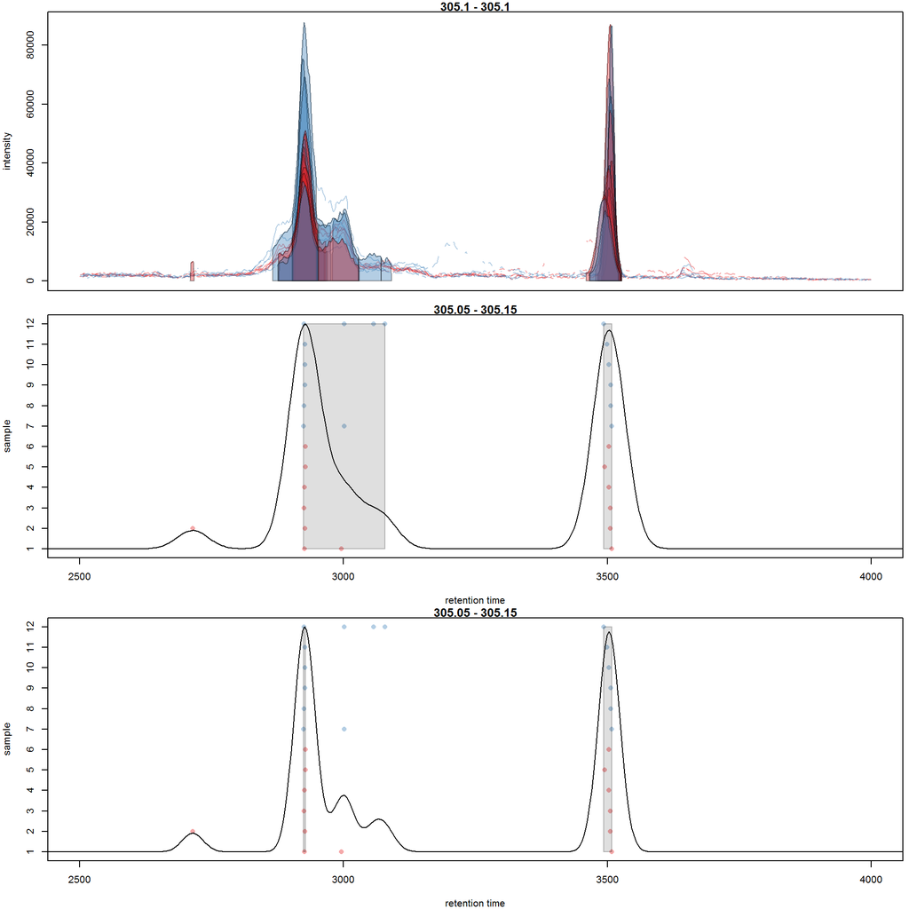

Figure 17: Example for peak density correspondence  
Upper panel: chromatogram for an mz slice with multiple chromatographic peaks. Middle and lower panel: identified chromatographic peaks at their retention time (x-axis) and index within samples of the experiments (y-axis) for different values of the bw parameter. The black line represents the peak density estimate. Grouping of peaks (based on the provided settings) is indicated by grey rectangles.

```r
## Define the mz slice.
mzr <- c(305.05, 305.15)

## Extract and plot the chromatograms
chr_mzr <- chromatogram(xdata, mz = mzr, rt = c(2500, 4000))
par(mfrow = c(3, 1), mar = c(1, 4, 1, 0.5))
cols <- group_colors[chr_mzr$sample_group]
plot(chr_mzr, col = cols, xaxt = "n", xlab = "",
     peakBg = sample_colors[chromPeaks(chr_mzr)[, "sample"]])
## Define the parameters for the peak density method
pdp <- PeakDensityParam(sampleGroups = xdata$sample_group,
                        minFraction = 0.4, bw = 30)
par(mar = c(4, 4, 1, 0.5))
plotChromPeakDensity(xdata, mz = mzr, col = cols, param = pdp,
                     pch = 16, xlim = c(2500, 4000))
## Use a different bw
pdp <- PeakDensityParam(sampleGroups = xdata$sample_group,
                        minFraction = 0.4, bw = 20)
plotChromPeakDensity(xdata, mz = mzr, col = cols, param = pdp,
                     pch = 16, xlim = c(2500, 4000))
```

The upper panel in the plot above shows the extracted ion chromatogram for each sample with the detected peaks highlighted. The middle and lower plot shows the retention time for each detected peak within the different samples. The black solid line represents the density distribution of detected peaks along the retention times. Peaks combined into *features* (peak groups) are indicated with grey rectangles. Different values for the `bw` parameter of the `PeakDensityParam` were used:`bw = 30` in the middle and `bw = 20` in the lower panel. With the default value for the parameter `bw` the two neighboring chromatographic peaks would be grouped into the same feature, while with a `bw` of 20 they would be grouped into separate features. This grouping depends on the parameters for the density function and other parameters passed to the algorithm with the `PeakDensityParam`.

```r
## Perform the correspondence
pdp <- PeakDensityParam(sampleGroups = xdata$sample_group,
                        minFraction = 0.4, bw = 20)
xdata <- groupChromPeaks(xdata, param = pdp)
```

The results from the correspondence can be extracted using the `featureDefinitions` method, that returns a `DataFrame` with the definition of the features (i.e. the mz and rt ranges and, in column `peakidx`, the index of the chromatographic peaks in the `chromPeaks` matrix for each feature).

```r
## Extract the feature definitions
featureDefinitions(xdata)
```

```
## DataFrame with 351 rows and 10 columns
##                  mzmed            mzmin            mzmax            rtmed
##              <numeric>        <numeric>        <numeric>        <numeric>
## FT001              205              205              205 2789.03721644709
## FT002              206              206              206 2788.30543697305
## FT003 207.100006103516 207.100006103516 207.100006103516 2718.79157726896
## FT004              233              233              233 3024.32548193573
## FT005 233.100006103516 233.100006103516 233.100006103516  3024.3863124223
## ...                ...              ...              ...              ...
## FT347 594.200012207031 594.200012207031 594.200012207031 3403.03259249868
## FT348 594.299987792969 594.299987792969 594.400024414062 3614.08509687872
## FT349 595.200012207031 595.200012207031 595.299987792969 3004.70699121539
## FT350 596.299987792969 596.299987792969 596.400024414062 3817.51017727276
## FT351 597.400024414062 597.299987792969 597.400024414062  3818.2445730933
##                  rtmin            rtmax    npeaks        KO        WT
##              <numeric>        <numeric> <numeric> <numeric> <numeric>
## FT001 2787.98587855926 2791.11395773677        12         6         6
## FT002 2786.42663550763 2791.18821663553        12         5         6
## FT003 2712.66710628365 2721.92752961577        13         5         4
## FT004 3014.17378362294 3058.09080263218        11         4         5
## FT005 3015.83729934739  3030.9739137208         5         4         1
## ...                ...              ...       ...       ...       ...
## FT347 3378.34778786262 3409.33220659131         6         1         5
## FT348  3608.8592486129 3662.82600472661        14         5         3
## FT349 2996.10745854437 3018.29416062423         8         2         4
## FT350  3803.8495800095 3825.79574827039        14         6         4
## FT351 3812.49998761581 3826.28011505943         6         2         3
##                                                                                    peakidx
##                                                                                     <list>
## FT001               c(68, 629, 1362, 1799, 2129, 2409, 2762, 3311, 3839, 4257, 4602, 4922)
## FT002               c(48, 614, 1342, 1350, 1790, 2397, 2743, 3299, 3820, 4242, 4588, 4909)
## FT003           c(30, 36, 599, 1327, 1335, 2110, 2382, 2724, 3282, 3796, 3797, 3803, 4891)
## FT004                   c(107, 1398, 2140, 2425, 2816, 2828, 3329, 3884, 4633, 4642, 4960)
## FT005                                                       c(101, 1394, 2143, 2429, 4639)
## ...                                                                                    ...
## FT347                                                c(2215, 2961, 3974, 4375, 4716, 5088)
## FT348  c(364, 373, 1025, 1037, 1589, 2300, 2301, 2589, 2604, 4060, 4771, 4785, 5177, 5210)
## FT349                                         c(94, 99, 751, 2819, 3882, 4630, 4953, 4964)
## FT350 c(481, 1197, 1673, 1677, 2044, 2331, 2649, 3653, 3656, 3660, 4142, 4522, 5265, 5269)
## FT351                                                c(1192, 1676, 4143, 4840, 4842, 5268)
```

```r
## Extract the into column for each feature.
head(featureValues(xdata, value = "into"))
```

```
##        ko15.CDF  ko16.CDF  ko18.CDF   ko19.CDF  ko21.CDF  ko22.CDF  wt15.CDF
## FT001 1924712.0 1757151.0 1714581.8 1220358.09 1383416.7 1180288.2 2129885.1
## FT002  213659.3  289500.7  194603.7   92590.27        NA  178285.7  253825.6
## FT003  349011.5  451863.7  337473.3         NA  343897.8  208002.8  364609.8
## FT004  286221.4        NA  364299.5         NA  137261.0  149097.6  255697.7
## FT005  162905.3        NA  209999.6         NA  164009.0  111157.9        NA
## FT006 1160580.5        NA 1345515.1  608016.51  380970.3  300716.1 1286883.0
##        wt16.CDF   wt18.CDF  wt19.CDF  wt21.CDF  wt22.CDF
## FT001 1634342.0 1810112.28 1507943.1 1623589.2 1354004.9
## FT002  241844.4  228501.09  216393.1  240606.0  185399.5
## FT003  360908.9   54566.86        NA        NA  221937.5
## FT004  311296.8  272267.90        NA  181640.2  271128.0
## FT005        NA         NA        NA  366441.5        NA
## FT006 1739516.6  515676.86  621437.9  639755.3  508546.4
```

This feature matrix contains `NA` for samples in which no chromatographic peak was detected in the feature’s m/z-rt region. While in many cases there might indeed be no peak signal in the respective region, it might also be that there is signal, but the peak detection algorithm failed to detect a chromatographic peak. `xcms` provides the `fillChromPeaks` method to *fill in* intensity data for such missing values from the original files. The *filled in* peaks are added to the `chromPeaks` matrix and get a `TRUE` value in the `"is_filled"` column of the `chromPeakData` data frame. Below we perform such a filling-in of missing peaks.

```r
## Filling missing peaks using default settings. Alternatively we could
## pass a FillChromPeaksParam object to the method.
xdata <- fillChromPeaks(xdata)

head(featureValues(xdata))
```

```
##        ko15.CDF  ko16.CDF  ko18.CDF   ko19.CDF  ko21.CDF  ko22.CDF  wt15.CDF
## FT001 1924712.0 1757151.0 1714581.8 1220358.09 1383416.7 1180288.2 2129885.1
## FT002  213659.3  289500.7  194603.7   92590.27  160248.3  178285.7  253825.6
## FT003  349011.5  451863.7  337473.3   95466.99  343897.8  208002.8  364609.8
## FT004  286221.4  303409.4  364299.5  190318.13  137261.0  149097.6  255697.7
## FT005  162905.3  137183.4  209999.6   50806.26  164009.0  111157.9  206488.1
## FT006 1160580.5 1245778.0 1345515.1  608016.51  380970.3  300716.1 1286883.0
##         wt16.CDF   wt18.CDF  wt19.CDF  wt21.CDF   wt22.CDF
## FT001 1634341.99 1810112.28 1507943.1 1623589.2 1354004.93
## FT002  241844.44  228501.09  216393.1  240606.0  185399.47
## FT003  360908.93   54566.86  160507.5  236586.5  221937.53
## FT004  311296.82  272267.90  126629.4  181640.2  271128.02
## FT005   38061.24  168155.16  106335.4  366441.5   71368.41
## FT006 1739516.56  515676.86  621437.9  639755.3  508546.42
```

For features without detected peaks in a sample, the method extracts all intensities in the mz-rt region of the feature, integrates the signal and adds a *filled-in* peak to the `chromPeaks` matrix. No peak is added if no signal is measured/available for the mz-rt region of the feature. For these, even after filling in missing peak data, a `NA` is reported in the `featureValues` matrix.

It should be mentioned that `fillChromPeaks` uses columns `"rtmin"`, `"rtmax"`, `"mzmin"` and `"mzmax"` from the `featureDefinitions` table to define the region from which the signal should be integrated to generate the filled-in peak signal. These values correspond however to the positions of the peak apex not the peak boundaries of all chromatographic peaks assigned to a feature. It might be advisable to increase this area in retention time dimension by a constant value appropriate to the average peak width in the experiment. Such a value can be specified with `fixedRt` of the `FillChromPeaksParam`. If the average peak width in the experiment is 20 seconds, specifying`fixedRt = 10` ensures that the area from which peaks are integrated is at least 20 seconds wide.

Below we compare the number of missing values before and after filling in missing values. We can use the parameter `filled` of the `featureValues` method to define whether or not filled-in peak values should be returned too.

```r
## Missing values before filling in peaks
apply(featureValues(xdata, filled = FALSE), MARGIN = 2,
      FUN = function(z) sum(is.na(z)))
```

```
## ko15.CDF ko16.CDF ko18.CDF ko19.CDF ko21.CDF ko22.CDF wt15.CDF wt16.CDF
##       72       74       69      119      142      114      101       96
## wt18.CDF wt19.CDF wt21.CDF wt22.CDF
##       95      128      136      118
```

```r
## Missing values after filling in peaks
apply(featureValues(xdata), MARGIN = 2,
      FUN = function(z) sum(is.na(z)))
```

```
## ko15.CDF ko16.CDF ko18.CDF ko19.CDF ko21.CDF ko22.CDF wt15.CDF wt16.CDF
##        7        8        4        8       12        8        8        9
## wt18.CDF wt19.CDF wt21.CDF wt22.CDF
##        9       13       13        7
```

Next we use the `featureSummary` function to get a general per-feature summary that includes the number of samples in which a peak was found or the number of samples in which more than one peak was assigned to the feature. Specifying also sample groups breaks down these summary statistics for each individual sample group.

```r
head(featureSummary(xdata, group = xdata$sample_group))
```

```
##       count      perc multi_count multi_perc       rsd KO_count   KO_perc
## FT001    12 100.00000           0   0.000000 0.1789898        6 100.00000
## FT002    11  91.66667           1   9.090909 0.2409441        5  83.33333
## FT003     9  75.00000           3  33.333333 0.2844117        5  83.33333
## FT004     9  75.00000           2  22.222222 0.3082528        4  66.66667
## FT005     5  41.66667           0   0.000000 0.4824173        4  66.66667
## FT006    11  91.66667           7  63.636364 0.5229604        5  83.33333
##       KO_multi_count KO_multi_perc    KO_rsd WT_count   WT_perc
## FT001              0             0 0.2027357        6 100.00000
## FT002              1            20 0.3653441        6 100.00000
## FT003              2            40 0.2562703        4  66.66667
## FT004              0             0 0.4694612        5  83.33333
## FT005              0             0 0.2492851        1  16.66667
## FT006              4            80 0.5059513        6 100.00000
##       WT_multi_count WT_multi_perc    WT_rsd
## FT001              0             0 0.1601279
## FT002              0             0 0.1069526
## FT003              1            25 0.3335925
## FT004              2            40 0.1840914
## FT005              0             0        NA
## FT006              3            50 0.5758382
```

The performance of peak detection, alignment and correspondence should always be evaluated by inspecting extracted ion chromatograms e.g. of known compounds, internal standards or identified features in general. The `featureChromatograms` function allows to extract chromatograms for each feature present in `featureDefinitions`. The returned `Chromatograms` object contains an ion chromatogram for each feature (each row containing the data for one feature) and sample (each column representing containing data for one sample). Below we extract the chromatograms for the first 4 features.

```r
feature_chroms <- featureChromatograms(xdata, features = 1:4)

feature_chroms
```

```
## XChromatograms with 4 rows and 12 columns
##                    1               2               3               4
##      <XChromatogram> <XChromatogram> <XChromatogram> <XChromatogram>
## [1,]        peaks: 1        peaks: 1        peaks: 1        peaks: 1
## [2,]        peaks: 1        peaks: 1        peaks: 2        peaks: 1
## [3,]        peaks: 2        peaks: 1        peaks: 2        peaks: 0
## [4,]        peaks: 1        peaks: 0        peaks: 1        peaks: 0
##                    5               6               7               8
##      <XChromatogram> <XChromatogram> <XChromatogram> <XChromatogram>
## [1,]        peaks: 1        peaks: 1        peaks: 1        peaks: 1
## [2,]        peaks: 0        peaks: 1        peaks: 1        peaks: 1
## [3,]        peaks: 1        peaks: 1        peaks: 1        peaks: 1
## [4,]        peaks: 1        peaks: 1        peaks: 2        peaks: 1
##                    9              10              11              12
##      <XChromatogram> <XChromatogram> <XChromatogram> <XChromatogram>
## [1,]        peaks: 1        peaks: 1        peaks: 1        peaks: 1
## [2,]        peaks: 1        peaks: 1        peaks: 1        peaks: 1
## [3,]        peaks: 3        peaks: 0        peaks: 0        peaks: 1
## [4,]        peaks: 1        peaks: 0        peaks: 2        peaks: 1
## phenoData with 2 variables
## featureData with 5 variables
## - - - xcms preprocessing - - -
## Chromatographic peak detection:
##  method: centWave
## Correspondence:
##  method: chromatographic peak density
##  4 feature(s) identified.
```

And plot the extracted ion chromatograms. We again use the group color for each identified peak to fill the area.

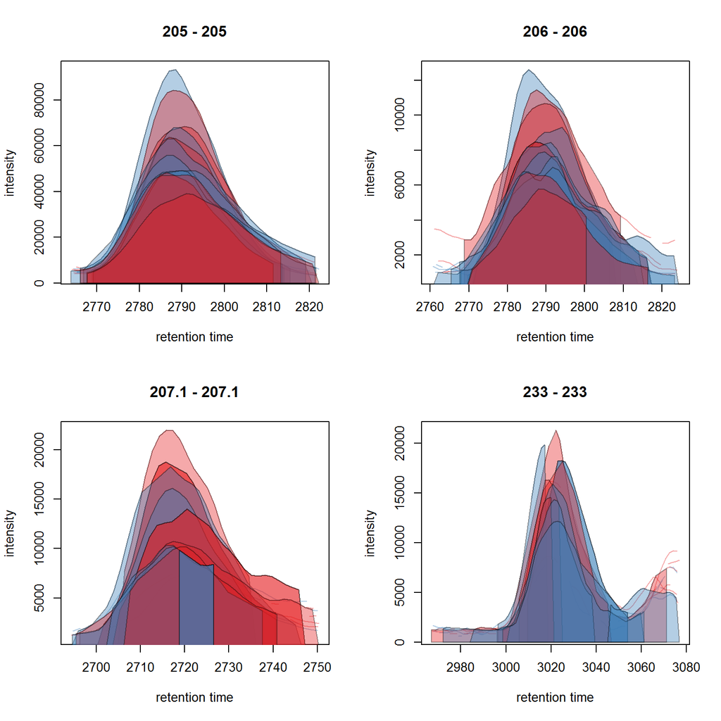

Figure 18: Extracted ion chromatograms for features 1 to 4

```r
plot(feature_chroms, col = sample_colors,
     peakBg = sample_colors[chromPeaks(feature_chroms)[, "sample"]])
```

```r
third <- feature_chroms[3, ]
plot(third)
chromPeaks(third)
```

```
##           mz mzmin mzmax       rt    rtmin    rtmax      into      intb
## CP0030 207.1 207.1 207.1 2717.287 2700.087 2740.539 349011.46 332229.06
## CP0036 207.1 207.1 207.1 2717.287 2700.087 2740.539 349011.46 333434.90
## CP0599 207.1 207.1 207.1 2718.906 2704.812 2736.095 451863.66 436882.86
## CP1327 207.1 207.1 207.1 2717.121 2703.610 2747.279 337473.31 335177.51
## CP1335 207.1 207.1 207.1 2717.121 2703.610 2747.279 337473.31 316857.85
## CP2110 207.1 207.1 207.1 2718.970 2695.379 2750.391 343897.76 314663.23
## CP2382 207.1 207.1 207.1 2721.928 2706.107 2740.880 208002.80 193780.31
## CP2724 207.1 207.1 207.1 2721.620 2694.290 2746.510 364609.77 343754.93
## CP3282 207.1 207.1 207.1 2718.792 2696.305 2740.815 360908.93 331504.06
## CP3796 207.1 207.1 207.1 2718.794 2718.794 2726.538  54566.86  50534.94
## CP3797 207.1 207.1 207.1 2712.667 2694.544 2726.538 182162.02 165026.92
## CP3803 207.1 207.1 207.1 2718.794 2718.794 2726.538  54566.86  51850.30
## CP4891 207.1 207.1 207.1 2717.368 2702.188 2737.638 221937.53 211243.04
##         maxo sn sample row column
## CP0030 18800 17      1   1      1
## CP0036 18800 17      1   1      1
## CP0599 22024 27      2   1      2
## CP1327 14035 47      3   1      3
## CP1335 14035 14      3   1      3
## CP2110 10746 12      5   1      5
## CP2382 10176 12      6   1      6
## CP2724 18280 19      7   1      7
## CP3282 16119 19      8   1      8
## CP3796  9822 13      9   1      9
## CP3797 10354 13      9   1      9
## CP3803  9822 11      9   1      9
## CP4891 10195 13     12   1     12
```

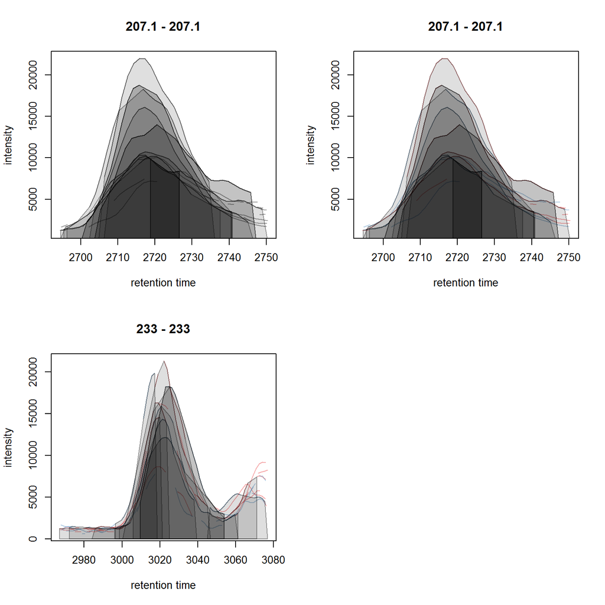

```r
plot(feature_chroms[3, ], col = group_colors[feature_chroms$sample_group])
plot(feature_chroms[4, ], col = group_colors[feature_chroms$sample_group])
```

At last we perform a principal component analysis to evaluate the grouping of the samples in this experiment. Note that we did not perform any data normalization hence the grouping might (and will) also be influenced by technical biases.

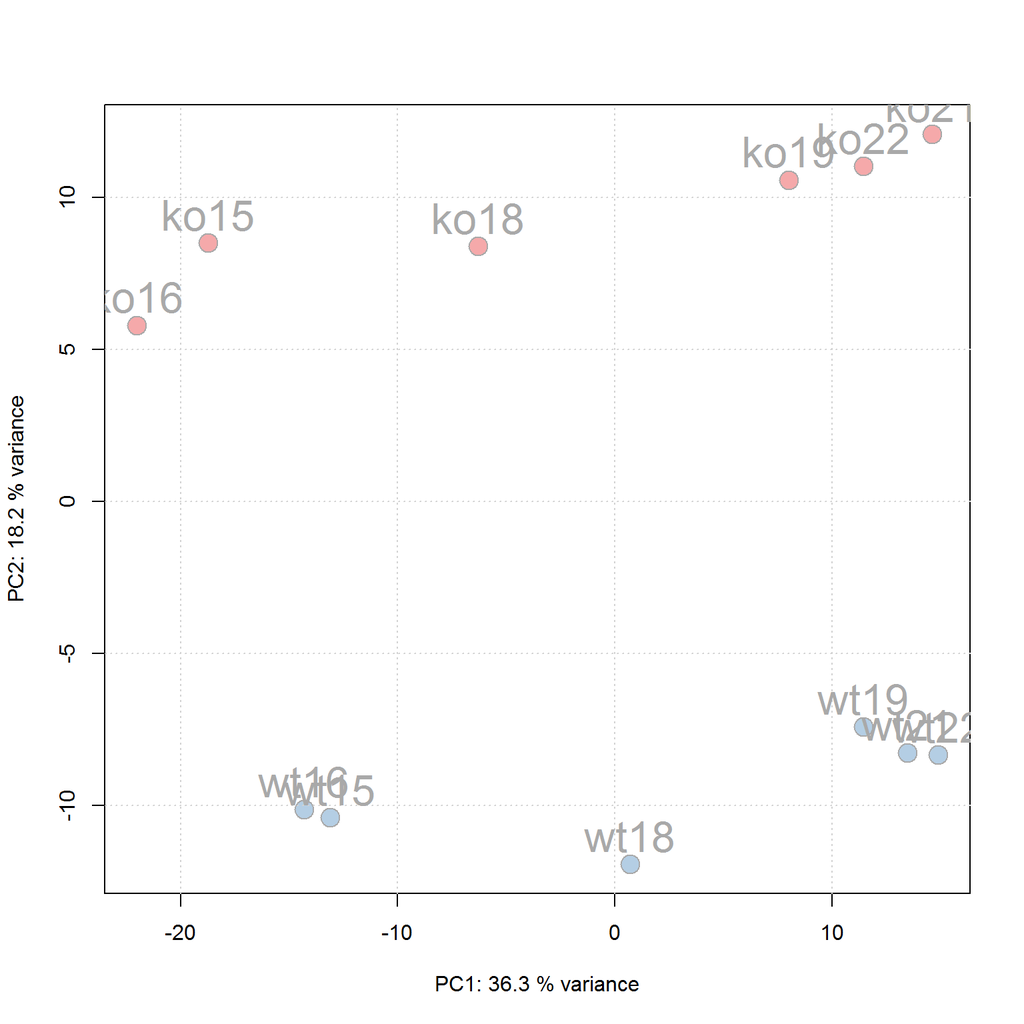

Figure 20: PCA for the faahKO data set, un-normalized intensities

```r
## Extract the features and log2 transform them
ft_ints <- log2(featureValues(xdata, value = "into"))

## Perform the PCA omitting all features with an NA in any of the
## samples. Also, the intensities are mean centered.
pc <- prcomp(t(na.omit(ft_ints)), center = TRUE)

## Plot the PCA
cols <- group_colors[xdata$sample_group]
pcSummary <- summary(pc)
plot(pc$x[, 1], pc$x[,2], pch = 21, main = "",
     xlab = paste0("PC1: ", format(pcSummary$importance[2, 1] * 100,
                                   digits = 3), " % variance"),
     ylab = paste0("PC2: ", format(pcSummary$importance[2, 2] * 100,
                                   digits = 3), " % variance"),
     col = "darkgrey", bg = cols, cex = 2)
grid()
text(pc$x[, 1], pc$x[,2], labels = xdata$sample_name, col = "darkgrey",
     pos = 3, cex = 2)
```

We can see the expected separation between the KO and WT samples on PC2. On PC1 samples separate based on their ID, samples with an ID <= 18 from samples with an ID > 18. This separation might be caused by a technical bias (e.g. measurements performed on different days/weeks) or due to biological properties of the mice analyzed (sex, age, litter mates etc).

# 7 Further data processing and analysis

Normalizing features’ signal intensities is required, but at present not (yet) supported in `xcms` (some methods might be added in near future). Also, for the identification of e.g. features with significant different intensities/abundances it is suggested to use functionality provided in other R packages, such as Bioconductor’s excellent `limma` package. To enable support also for other packages that rely on the *old* `xcmsSet` result object, it is possible to coerce the new `XCMSnExp` object to an `xcmsSet` object using `xset <- as(x, "xcmsSet")`, with `x` being an `XCMSnExp` object.

# 8 Additional details and notes

For a detailed description of the new data objects and changes/improvements compared to the original user interface see the *new_functionality* vignette.

## 8.1 Evaluating the process history

`XCMSnExp` objects allow to capture all performed pre-processing steps along with the used parameter class within the `@processHistory` slot. Storing also the parameter class ensures the highest possible degree of analysis documentation and in future might enable to *replay* analyses or parts of it. The list of all performed preprocessings can be extracted using the `processHistory` method.

```r
processHistory(xdata)
```

```
## [[1]]
## Object of class "XProcessHistory"
##  type: Peak detection
##  date: Thu May 16 21:10:14 2019
##  info:
##  fileIndex: 1,2,3,4,5,6,7,8,9,10,11,12
##  Parameter class: CentWaveParam
##  MS level(s) 1
##
## [[2]]
## Object of class "XProcessHistory"
##  type: Peak grouping
##  date: Thu May 16 21:11:27 2019
##  info:
##  fileIndex: 1,2,3,4,5,6,7,8,9,10,11,12
##  Parameter class: PeakDensityParam
##  MS level(s) 1
##
## [[3]]
## Object of class "XProcessHistory"
##  type: Retention time correction
##  date: Thu May 16 21:11:28 2019
##  info:
##  fileIndex: 1,2,3,4,5,6,7,8,9,10,11,12
##  Parameter class: PeakGroupsParam
##  MS level(s) 1
##
## [[4]]
## Object of class "XProcessHistory"
##  type: Peak grouping
##  date: Thu May 16 21:12:14 2019
##  info:
##  fileIndex: 1,2,3,4,5,6,7,8,9,10,11,12
##  Parameter class: PeakDensityParam
##  MS level(s) 1
##
## [[5]]
## Object of class "XProcessHistory"
##  type: Missing peak filling
##  date: Thu May 16 21:12:15 2019
##  info:
##  fileIndex: 1,2,3,4,5,6,7,8,9,10,11,12
##  Parameter class: FillChromPeaksParam
##  MS level(s) 1
```

It is also possible to extract specific processing steps by specifying its type. Available *types* can be listed with the `processHistoryTypes` function. Below we extract the parameter class for the alignment/retention time adjustment step.

```r
ph <- processHistory(xdata, type = "Retention time correction")

ph
```

```
## [[1]]
## Object of class "XProcessHistory"
##  type: Retention time correction
##  date: Thu May 16 21:11:28 2019
##  info:
##  fileIndex: 1,2,3,4,5,6,7,8,9,10,11,12
##  Parameter class: PeakGroupsParam
##  MS level(s) 1
```

And we can also extract the parameter class used in this preprocessing step.

```r
## Access the parameter
processParam(ph[[1]])
```

```
## Object of class:  PeakGroupsParam
## Parameters:
##  minFraction: 0.85
##  extraPeaks: 1
##  smooth: loess
##  span: 0.2
##  family: gaussian
##  subset:
##  number of peak groups: 39
```

## 8.2 Subsetting and filtering

`XCMSnEx` objects can be subsetted/filtered using the `[` method, or one of the many `filter*` methods. All these methods aim to ensure that the data in the returned object is consistent. This means for example that if the object is subsetted by selecting specific spectra (by using the `[` method) all identified chromatographic peaks are removed. Correspondence results (i.e. identified features) are removed if the object is subsetted to contain only data from selected files (using the `filterFile` method). This is because the correspondence results depend on the files on which the analysis was performed - running a correspondence on a subset of the files would lead to different results.

As an exception, it is possible to force keeping adjusted retention times in the subsetted object setting the `keepAdjustedRtime` argument to `TRUE` in any of the subsetting methods.

Below we subset our results object the data for the files 2 and 4.

```r
subs <- filterFile(xdata, file = c(2, 4))

## Do we have identified chromatographic peaks?
hasChromPeaks(subs)
```

```
## [1] TRUE
```

Peak detection is performed separately on each file, thus the subsetted object contains all identified chromatographic peaks from the two files. However, we used a retention time adjustment (alignment) that was based on available features. All features have however been removed and also the adjusted retention times (since the alignment based on features that were identified on chromatographic peaks on all files).

```r
## Do we still have features?
hasFeatures(subs)
```

```
## [1] FALSE
```

```r
## Do we still have adjusted retention times?
hasAdjustedRtime(subs)
```

```
## [1] FALSE
```

We can however use the `keepAdjustedRtime` argument to force keeping the adjusted retention times.

```r
subs <- filterFile(xdata, keepAdjustedRtime = TRUE)

hasAdjustedRtime(subs)
```

```
## [1] TRUE
```

The `filterRt` method can be used to subset the object to spectra within a certain retention time range.

```r
subs <- filterRt(xdata, rt = c(3000, 3500))

range(rtime(subs))
```

```
## [1] 3000.027 3499.994
```

Filtering by retention time does not change/affect adjusted retention times (also, if adjusted retention times are present, the filtering is performed **on** the adjusted retention times).

```r
hasAdjustedRtime(subs)
```

```
## [1] TRUE
```

Also, we have all identified chromatographic peaks within the specified retention time range:

```r
hasChromPeaks(subs)
```

```
## [1] TRUE
```

```r
range(chromPeaks(subs)[, "rt"])
```

```
## [1] 3001.260 3499.994
```

The most natural way to subset any object in R is with `[`. Using `[` on an `XCMSnExp` object subsets it keeping only the selected spectra. The index `i` used in `[` has thus to be an integer between 1 and the total number of spectra (across all files). Below we subset `xdata` using both `[` and `filterFile` to keep all spectra from one file.

```r
## Extract all data from the 3rd file.
one_file <- filterFile(xdata, file = 3)

one_file_2 <- xdata[fromFile(xdata) == 3]

## Is the content the same?
all.equal(spectra(one_file), spectra(one_file_2))
```

```
## [1] TRUE
```

While the spectra-content is the same in both objects, `one_file` contains also the identified chromatographic peaks while `one_file_2` does not. Thus, in most situations subsetting using one of the filter functions is preferred over the use of `[`.

```r
## Subsetting with filterFile preserves chromatographic peaks
head(chromPeaks(one_file))
```

```
##         mz mzmin mzmax       rt    rtmin    rtmax      into      intb   maxo
## CP1303 316   316   316 2517.029 2501.379 2535.808  741708.6  727319.6  27816
## CP1304 333   333   333 2515.464 2501.379 2540.503  960445.7  942106.5  33992
## CP1305 338   338   338 2517.029 2501.379 2540.503  788766.4  758962.1  29288
## CP1306 332   332   332 2517.029 2501.379 2545.198 4870388.0 4768520.5 169280
## CP1307 315   315   315 2515.464 2501.379 2540.503 3714288.6 3634444.9 131136
## CP1308 337   337   337 2517.029 2501.379 2549.893 4356732.5 4216751.1 142720
##        sn sample
## CP1303 47      1
## CP1304 42      1
## CP1305 35      1
## CP1306 92      1
## CP1307 95      1
## CP1308 83      1
```

```r
## Subsetting with [ not
head(chromPeaks(one_file_2))
```

[output not shown]

Note however that also `[` does support the `keepAdjustedRtime` argument. Below we subset the object to spectra 20:30.

```r
subs <- xdata[20:30, keepAdjustedRtime = TRUE]
hasAdjustedRtime(subs)
```

```
## [1] TRUE
```

```r
## Access adjusted retention times:
rtime(subs)
```

```
## F01.S0020 F01.S0021 F01.S0022 F01.S0023 F01.S0024 F01.S0025 F01.S0026
##  2535.977  2537.542  2539.107  2540.672  2542.237  2543.802  2545.367
## F01.S0027 F01.S0028 F01.S0029 F01.S0030
##  2546.932  2548.497  2550.062  2551.627
```

```r
## Access raw retention times:
rtime(subs, adjusted = FALSE)
```

```
## F01.S0020 F01.S0021 F01.S0022 F01.S0023 F01.S0024 F01.S0025 F01.S0026
##  2531.112  2532.677  2534.242  2535.807  2537.372  2538.937  2540.502
## F01.S0027 F01.S0028 F01.S0029 F01.S0030
##  2542.067  2543.632  2545.197  2546.762
```

As with `MSnExp` and `OnDiskMSnExp` objects, `[[` can be used to extract a single spectrum object from an `XCMSnExp` object. The retention time of the spectrum corresponds to the adjusted retention time if present.

```r
## Extract a single spectrum
xdata[[14]]
```

```
## Object of class "Spectrum1"
##  Retention time: 42:7
##  MSn level: 1
##  Total ion count: 445
##  Polarity: NA
```

At last we can also use the `split` method that allows to split an `XCMSnExp` based on a provided factor `f`. Below we split `xdata` per file. Using `keepAdjustedRtime = TRUE` ensures that adjusted retention times are not removed.

```r
x_list <- split(xdata, f = fromFile(xdata), keepAdjustedRtime = TRUE)

lengths(x_list)
```

```
##    1    2    3    4    5    6    7    8    9   10   11   12
## 1278 1278 1278 1278 1278 1278 1278 1278 1278 1278 1278 1278
```

```r
lapply(x_list, hasAdjustedRtime)
```

```
## $`1`
## [1] TRUE
##
## $`2`
## [1] TRUE
##
## $`3`
## [1] TRUE
##
## $`4`
## [1] TRUE
##
## $`5`
## [1] TRUE
##
## $`6`
## [1] TRUE
##
## $`7`
## [1] TRUE
##
## $`8`
## [1] TRUE
##
## $`9`
## [1] TRUE
##
## $`10`
## [1] TRUE
##
## $`11`
## [1] TRUE
##
## $`12`
## [1] TRUE
```

Note however that there is also a dedicated `splitByFile` method instead for that operation, that internally uses `filterFile` and hence does e.g. not remove identified chromatographic peaks. The method does not yet support the `keepAdjustedRtime` parameter and thus removes by default adjusted retention times.

```r
xdata_by_file <- splitByFile(xdata, f = factor(1:length(fileNames(xdata))))

lapply(xdata_by_file, hasChromPeaks)
```

```
## $`1`
## [1] TRUE
##
## $`2`
## [1] TRUE
##
## $`3`
## [1] TRUE
##
## $`4`
## [1] TRUE
##
## $`5`
## [1] TRUE
##
## $`6`
## [1] TRUE
##
## $`7`
## [1] TRUE
##
## $`8`
## [1] TRUE
##
## $`9`
## [1] TRUE
##
## $`10`
## [1] TRUE
##
## $`11`
## [1] TRUE
##
## $`12`
## [1] TRUE
```

## 8.3 Parallel processing

Most methods in `xcms` support parallel processing. Parallel processing is handled and configured by the `BiocParallel` Bioconductor package and can be globally defined for an R session.

Unix-based systems (Linux, macOS) support `multicore`-based parallel processing. To configure it globally we `register` the parameter class. Note also that `bpstart` is used below to initialize the parallel processes.

```r
register(bpstart(MulticoreParam(2)))
```

Windows supports only socket-based parallel processing:

```r
register(bpstart(SnowParam(2)))
```

Note that `multicore`-based parallel processing might be buggy or failing on macOS. If so, the `DoparParam` could be used instead (requiring the `foreach` package).

For other options and details see the vignettes from the `BiocParallel` package.

# References

1. Saghatelian A, Trauger SA, Want EJ, Hawkins EG, Siuzdak G, Cravatt BF: **Assignment of endogenous substrates to enzymes by global metabolite profiling**. *Biochemistry* 2004, **43**:14332–9.

2. Tautenhahn R, Böttcher C, Neumann S: **Highly sensitive feature detection for high resolution LC/MS.** *BMC Bioinformatics* 2008, **9**:504.

3. Smith R, Ventura D, Prince JT: **LC-MS alignment in theory and practice: a comprehensive algorithmic review.** *Briefings in bioinformatics* 2013, **16**:bbt080–117.

4. Prince JT, Marcotte EM: **Chromatographic alignment of ESI-LC-MS proteomics data sets by ordered bijective interpolated warping.** *Analytical chemistry* 2006, **78**:6140–6152.

5. Smith CA, Want EJ, O’Maille G, Abagyan R, Siuzdak G: **XCMS: processing mass spectrometry data for metabolite profiling using nonlinear peak alignment, matching, and identification.** *Analytical chemistry* 2006, **78**:779–787.